# Tugas Mandiri Praktikum 1-MPDW

Hafidz Candra Ramadhan_G1401221079

2024-08-25

## Library

kita akan menggunakan library sebagai berikut:

```r
#library yang akan digunakan
library("forecast")
```

```r
library("graphics")
library("TTR")
library("TSA")
library("rio")
```

## Memanggil Data

Data yang kelompok saya gunakan adalah Data Jumlah Penumpang Transjakarta Harian Tahun 2023-2024 yang diperoleh dari website “Satu Data Indonesia”. Data ini sudah di upload ke github dan bisa diakses melalui link berikut: https://raw.githubusercontent.com/SandraBerlianaPutri/Kelompok-7-MPDW-P1/main/Data%20Jumlah%20Penumpang%20Transjakarta%20Harian%20Tahun%202023-2024.csv?token=GHSAT0AAAAAACWKXWTNVUZF7GVCKTH5FAYQZWLMJAA

```r
#memanggil data
data_mpdw <- read.csv("D:\\IPB\\Statistika Sem 5\\MPDW (Deret Waktu)\\Data Jumlah Penumpang Transjakarta Harian Tahun 2023-2024.csv", sep =";")
head(data_mpdw)
```

```
##   periode_data jumlah_penumpang_transjakarta tanggal X
## 1   01/01/2023                        363250       1
## 2   02/01/2023                        730984       2
## 3   03/01/2023                        783228       3
## 4   04/01/2023                        798449       4
## 5   05/01/2023                        807905       5
## 6   06/01/2023                        807617       6
```

kita hanya menggunakan data dari periode ke-219 sampai 327 dan kolom periode data serta jumlah penumpang transjakarta

```r
#ambil baris ke-219 sampai 327 dan kolom 1 sampai 2
data_mpdw <- data_mpdw[219:327,1:2]

#merubah kolom periode data menjadi angka berurut
data_mpdw$periode_data <- 1:nrow(data_mpdw)
head(data_mpdw)
```

```
##     periode_data jumlah_penumpang_transjakarta
## 219            1                       1006666
## 220            2                       1011406
## 221            3                       1000208
## 222            4                        991508
## 223            5                        982905
## 224            6                        676818
```

## Eksplorasi Data

Kita akan melihat data, struktur data, dimensi data, dan summary dari data yang kita gunakan

```r
View(data_mpdw)
str(data_mpdw)
```

```
## 'data.frame':    109 obs. of  2 variables:
##  $ periode_data                 : int  1 2 3 4 5 6 7 8 9 10 ...
##  $ jumlah_penumpang_transjakarta: int  1006666 1011406 1000208 991508 982905 676818 597413 1008471 1011261 989925 ...
```

```r
dim(data_mpdw)
```

```
## [1] 109   2
```

```r
summary(data_mpdw)
```

```
##   periode_data jumlah_penumpang_transjakarta
##  Min.   :  1   Min.   : 246739
##  1st Qu.: 28   1st Qu.: 654569
##  Median : 55   Median :1026591
##  Mean   : 55   Mean   : 898693
##  3rd Qu.: 82   3rd Qu.:1105993
##  Max.   :109   Max.   :1171288
```

mengubah data menjadi time series data dengan fungsi ts()

```r
data_mpdw.ts <- ts(data_mpdw$jumlah_penumpang_transjakarta)
```

menampilkan ringkasan data time series

```r
summary(data_mpdw.ts)
```

```
##    Min. 1st Qu.  Median    Mean 3rd Qu.    Max.
##  246739  654569 1026591  898693 1105993 1171288
```

```r
View(data_mpdw.ts)
```

membuat plot data time series

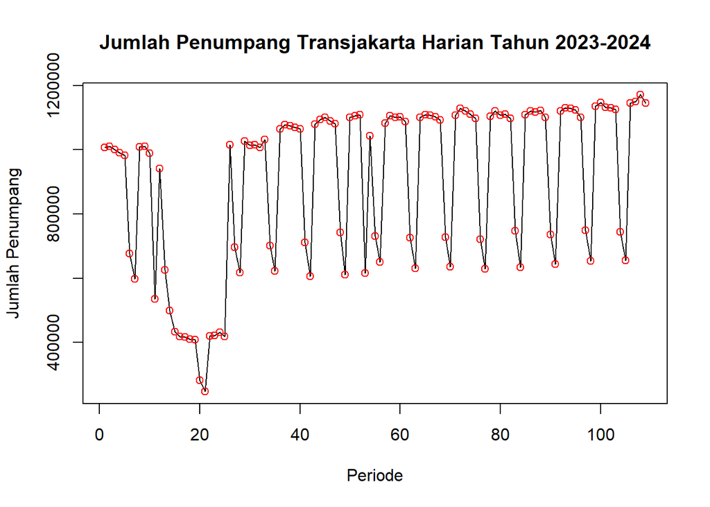

```r
plot(data_mpdw.ts, main="Jumlah Penumpang Transjakarta Harian Tahun 2023-2024", xlab="Periode", ylab="Jumlah Penumpang")
points(data_mpdw.ts, col="red")
```

## Single Moving Average & Double Moving Average

### Pembagian Data

cara membagi datanya biasanya adalah 80% data train dan 20% data testing, tapi kalau untuk time series tidak bisa sembarang membagi data (jangan diujung tren tetapi ditengah tren, semisal jangan diujung data ketika baru ingin naik atau ingin turun). Namun karena data ini tergolong grafiknya stasioner, maka bisa dibagi 80% data train dan 20% data testing

```r
#data 1 sampai 87 merupakan data training
train_mpdw <- data_mpdw[1:87,]
#merubah data training menjadi time series
train_mpdw.ts <- ts(train_mpdw$jumlah_penumpang_transjakarta)
train_mpdw.ts
```

```
## Time Series:
## Start = 1
## End = 87
## Frequency = 1
##  [1] 1006666 1011406 1000208  991508  982905  676818  597413 1008471 1011261
## [10]  989925  535537  941749  625534  498446  433517  418970  416837  409463
## [19]  408345  282422  246739  420126  422024  430748  417971 1015361  695963
## [28]  617558 1026591 1014345 1014851 1007231 1032009  700670  621726 1065550
## [37] 1078830 1074826 1070391 1064895  711037  605562 1080611 1094329 1101370
## [46] 1090495 1081846  742942  611442 1100966 1105993 1109120  615710 1043002
## [55]  730363  650239 1083284 1105891 1100992 1102279 1087623  725319  630556
## [64] 1100382 1109216 1107503 1103250 1093067  727497  635855 1107316 1128713
## [73] 1121625 1110376 1097821  721052  629687 1104758 1120393 1107625 1111359
## [82] 1097914  748153  633768 1109764 1121596 1117922
```

```r
#data 88 sampai 109 merupakan data testing
test_mpdw <- data_mpdw[88:109,]
#merubah data testing menjadi time series
test_mpdw.ts <- ts(test_mpdw$jumlah_penumpang_transjakarta)
```

### Eksplorasi Data

kita akan mengeksplorasi data keseluruhan, data training, dan data testing

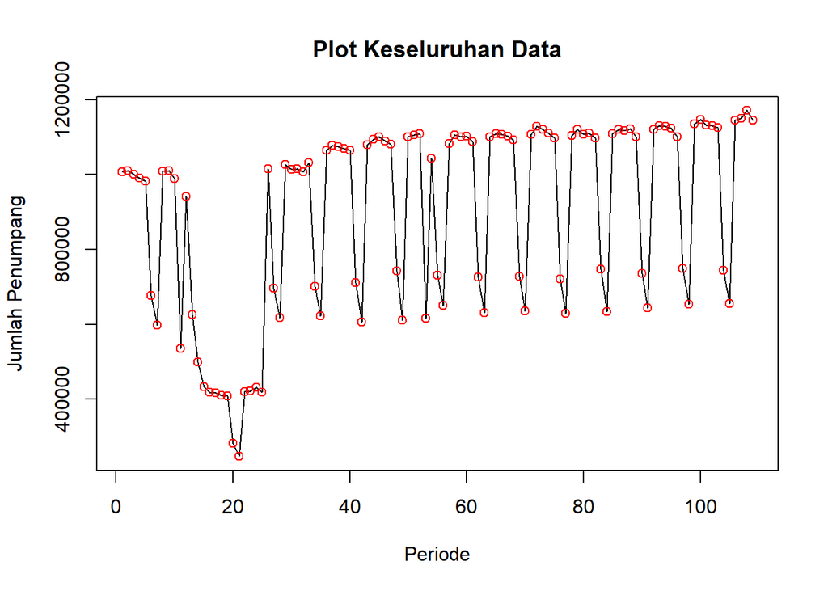

```r
#plot data keseluruhan
plot(data_mpdw.ts, col = "black", main = "Plot Keseluruhan Data", xlab = "Periode", ylab = "Jumlah Penumpang")
points(data_mpdw.ts, col="red")
```

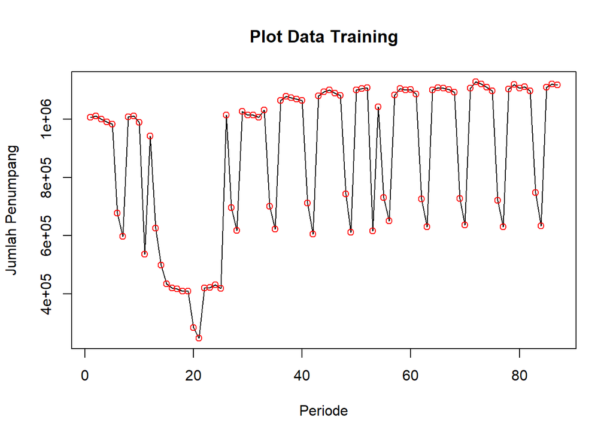

```r
#plot data training
plot(train_mpdw.ts, col = "black", main = "Plot Data Training", xlab = "Periode", ylab = "Jumlah Penumpang")
points(train_mpdw.ts, col="red")
```

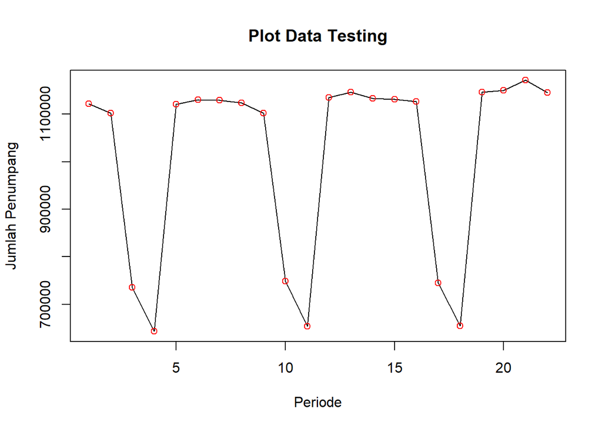

```r
#plot data testing
plot(test_mpdw.ts, col = "black", main = "Plot Data Testing", xlab = "Periode", ylab = "Jumlah Penumpang")
points(test_mpdw.ts, col="red")
```

Selain dengan cara diatas kita juga bisa menggunakan package ggplot2 untuk mengeksplorasi data

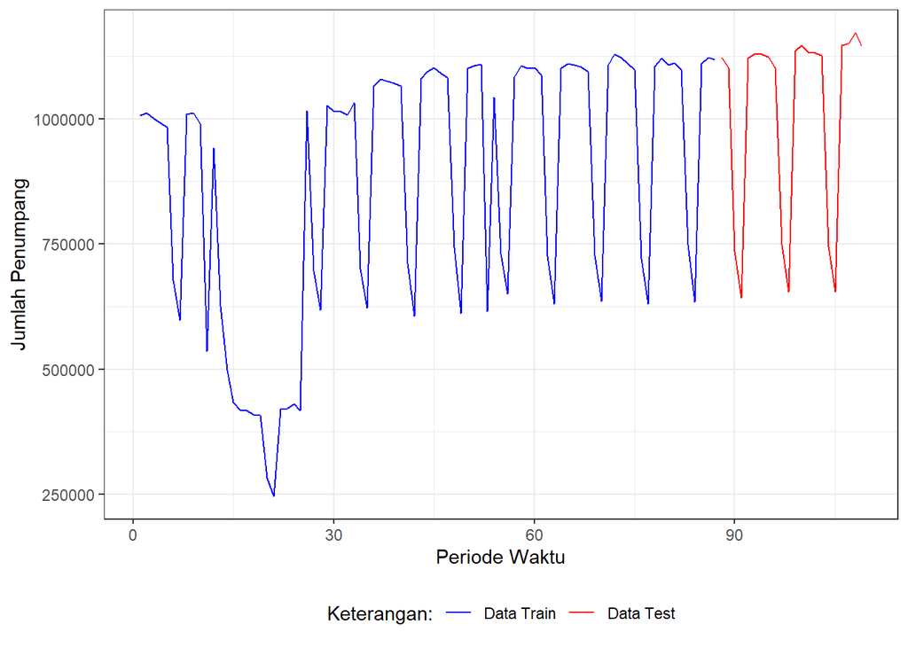

```r
library(ggplot2)
ggplot() +
  geom_line(data = train_mpdw, aes(x = periode_data, y = jumlah_penumpang_transjakarta, col = "Data Train")) +
  geom_line(data = test_mpdw, aes(x = periode_data, y = jumlah_penumpang_transjakarta, col = "Data Test")) +
  labs(x = "Periode Waktu", y = "Jumlah Penumpang", color = "Legend") +
  scale_colour_manual(name="Keterangan:", breaks = c("Data Train", "Data Test"),
                      values = c("blue", "red")) +
  theme_bw() + theme(legend.position = "bottom",
                     plot.caption = element_text(hjust=0.5, size=12))
```

```r
train_mpdw
```

```
##     periode_data jumlah_penumpang_transjakarta
## 219            1                       1006666
## 220            2                       1011406
## 221            3                       1000208
## 222            4                        991508
## 223            5                        982905
## 224            6                        676818
## 225            7                        597413
## 226            8                       1008471
## 227            9                       1011261
## 228           10                        989925
## 229           11                        535537
## 230           12                        941749
## 231           13                        625534
## 232           14                        498446
```

[output cut: 73 more lines]

data terputus karena langsung dibedakan warna, kita harus membuat satu warna terlebih dahulu baru ditimpa warna merah, seperti berikut :

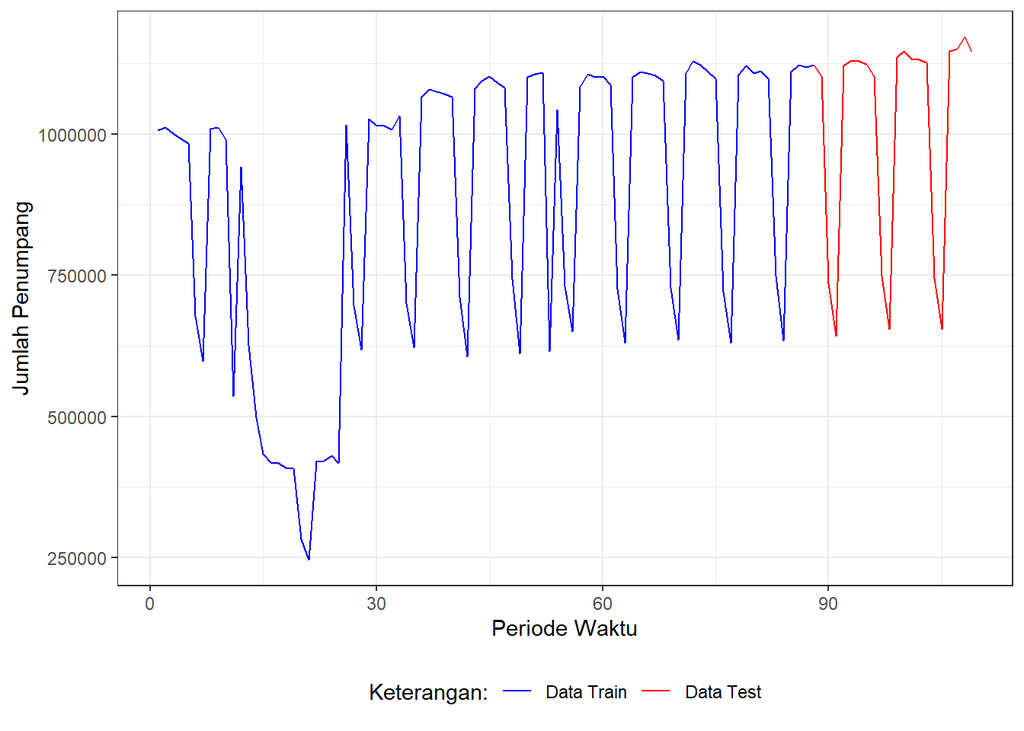

```r
library(ggplot2)
ggplot() +
  geom_line(data = data_mpdw, aes(x = periode_data, y = jumlah_penumpang_transjakarta, col = "Data Train")) +
  geom_line(data = test_mpdw, aes(x = periode_data, y = jumlah_penumpang_transjakarta, col = "Data Test")) +
  labs(x = "Periode Waktu", y = "Jumlah Penumpang", color = "Legend") +
  scale_colour_manual(name="Keterangan:", breaks = c("Data Train", "Data Test"),
                      values = c("blue", "red")) +
  theme_bw() + theme(legend.position = "bottom",
                     plot.caption = element_text(hjust=0.5, size=12))
```

### Single Moving Average (SMA)

Ide dasar dari Single Moving Average (SMA) adalah data suatu periode dipengaruhi oleh data periode sebelumnya. Metode pemulusan ini cocok digunakan untuk pola data stasioner atau konstan. Prinsip dasar metode pemulusan ini adalah data pemulusan pada periode ke-t merupakan rata rata dari m buah data pada periode ke-t hingga periode ke (t-m+1). Data pemulusan pada periode ke-t selanjutnya digunakan sebagai nilai peramalan pada periode ke t+1

Pemulusan menggunakan metode SMA dilakukan dengan fungsi `SMA()`. Dalam hal ini akan dilakukan pemulusan dengan parameter `m=3`.

```r
#single moving average
sma_mpdw <- SMA(train_mpdw.ts, n=3)
sma_mpdw
```

```
## Time Series:
## Start = 1
## End = 87
## Frequency = 1
##  [1]        NA        NA 1006093.3 1001040.7  991540.3  883743.7  752378.7
##  [8]  760900.7  872381.7 1003219.0  845574.3  822403.7  700940.0  688576.3
## [15]  519165.7  450311.0  423108.0  415090.0  411548.3  366743.3  312502.0
## [22]  316429.0  362963.0  424299.3  423581.0  621360.0  709765.0  776294.0
## [29]  780037.3  886164.7 1018595.7 1012142.3 1018030.3  913303.3  784801.7
## [36]  795982.0  922035.3 1073068.7 1074682.3 1070037.3  948774.3  793831.3
## [43]  799070.0  926834.0 1092103.3 1095398.0 1091237.0  971761.0  812076.7
## [50]  818450.0  939467.0 1105359.7  943607.7  922610.7  796358.3  807868.0
## [57]  821295.3  946471.3 1096722.3 1103054.0 1096964.7  971740.3  814499.3
## [64]  818752.3  946718.0 1105700.3 1106656.3 1101273.3  974604.7  818806.3
## [71]  823556.0  957294.7 1119218.0 1120238.0 1109940.7  976416.3  816186.7
## [78]  818499.0  951612.7 1110925.3 1113125.7 1105632.7  985808.7  826611.7
## [85]  830561.7  955042.7 1116427.3
```

Data pemulusan pada periode ke-t selanjutnya digunakan sebagai nilai peramalan pada periode ke t+1 sehingga hasil peramalan 1 periode kedepan adalah sebagai berikut.

```r
#peramalan 1 periode kedepan
ramal_sma <- c(NA, sma_mpdw)
ramal_sma
```

```
##  [1]        NA        NA        NA 1006093.3 1001040.7  991540.3  883743.7
##  [8]  752378.7  760900.7  872381.7 1003219.0  845574.3  822403.7  700940.0
## [15]  688576.3  519165.7  450311.0  423108.0  415090.0  411548.3  366743.3
## [22]  312502.0  316429.0  362963.0  424299.3  423581.0  621360.0  709765.0
## [29]  776294.0  780037.3  886164.7 1018595.7 1012142.3 1018030.3  913303.3
## [36]  784801.7  795982.0  922035.3 1073068.7 1074682.3 1070037.3  948774.3
## [43]  793831.3  799070.0  926834.0 1092103.3 1095398.0 1091237.0  971761.0
## [50]  812076.7  818450.0  939467.0 1105359.7  943607.7  922610.7  796358.3
## [57]  807868.0  821295.3  946471.3 1096722.3 1103054.0 1096964.7  971740.3
## [64]  814499.3  818752.3  946718.0 1105700.3 1106656.3 1101273.3  974604.7
## [71]  818806.3  823556.0  957294.7 1119218.0 1120238.0 1109940.7  976416.3
## [78]  816186.7  818499.0  951612.7 1110925.3 1113125.7 1105632.7  985808.7
## [85]  826611.7  830561.7  955042.7 1116427.3
```

```r
View(ramal_sma)
```

Selanjutnya akan dilakukan peramalan sejumlah data uji yaitu 22 periode. Pada metode SMA, hasil peramalan 22 periode ke depan akan bernilai sama dengan hasil peramalan 1 periode kedepan. Dalam hal ini akan dilakukan pengguabungan data aktual train, data hasil pemulusan dan data hasil ramalan 22 periode kedepan.

```r
#peramalan 22 periode kedepan
data_gab<-cbind(aktual=c(train_mpdw.ts,rep(NA,22)),pemulusan=c(sma_mpdw,rep(NA,22)),ramalan=c(ramal_sma,rep(ramal_sma[length(ramal_sma)],21)))
data_gab #forecast 12 periode ke depan
```

```
##         aktual pemulusan   ramalan
##   [1,] 1006666        NA        NA
##   [2,] 1011406        NA        NA
##   [3,] 1000208 1006093.3        NA
##   [4,]  991508 1001040.7 1006093.3
##   [5,]  982905  991540.3 1001040.7
##   [6,]  676818  883743.7  991540.3
##   [7,]  597413  752378.7  883743.7
##   [8,] 1008471  760900.7  752378.7
##   [9,] 1011261  872381.7  760900.7
##  [10,]  989925 1003219.0  872381.7
##  [11,]  535537  845574.3 1003219.0
##  [12,]  941749  822403.7  845574.3
##  [13,]  625534  700940.0  822403.7
##  [14,]  498446  688576.3  700940.0
```

[output cut: 95 more lines]

```r
View(data_gab)
```

Adapun plot data deret waktu dari hasil peramalan yang dilakukan adalah sebagai berikut.

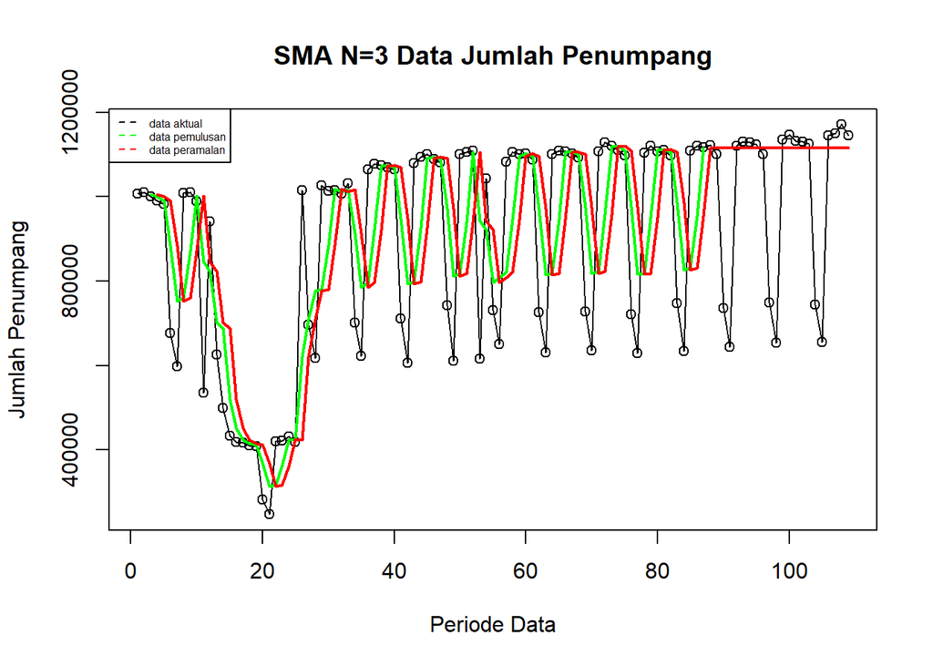

```r
ts.plot(data_mpdw.ts, xlab="Periode Data", ylab="Jumlah Penumpang", main= "SMA N=3 Data Jumlah Penumpang")
points(data_mpdw.ts)
lines(data_gab[,2],col="green",lwd=2)
lines(data_gab[,3],col="red",lwd=2)
legend("topleft",c("data aktual","data pemulusan","data peramalan"), lty=8, col=c("black","green","red"), cex=0.5)
```

Selanjutnya perhitungan akurasi dilakukan dengan ukuran akurasi *Sum Squares Error* (SSE), *Mean Square Error* (MSE) dan *Mean Absolute Percentage Error* (MAPE). Perhitungan akurasi dilakukan baik pada data latih maupun pada data uji.

```r
#menghitung akurasi data latih
error_train_sma = train_mpdw.ts-ramal_sma[1:length(train_mpdw.ts)]
SSE_train_sma = sum(error_train_sma[5:length(train_mpdw.ts)]^2)
MSE_train_sma = mean(error_train_sma[5:length(train_mpdw.ts)]^2)
MAPE_train_sma = mean(abs((error_train_sma[5:length(train_mpdw.ts)]/train_mpdw.ts[5:length(train_mpdw.ts)])*100))

akurasi_train_sma <- matrix(c(SSE_train_sma, MSE_train_sma, MAPE_train_sma))
row.names(akurasi_train_sma)<- c("SSE", "MSE", "MAPE")
colnames(akurasi_train_sma) <- c("Akurasi N = 3")
akurasi_train_sma
```

```
##      Akurasi N = 3
## SSE   4.833368e+12
## MSE   5.823335e+10
## MAPE  2.584514e+01
```

Selanjutnya, kita akan menghitung akurasi pada data uji

```r
#menghitung akurasi data uji
error_test_sma = test_mpdw.ts-data_gab[88:109,3]
SSE_test_sma = sum(error_test_sma^2)
MSE_test_sma = mean(error_test_sma^2)
MAPE_test_sma = mean(abs((error_test_sma/test_mpdw.ts*100)))

akurasi_test_sma <- matrix(c(SSE_test_sma, MSE_test_sma, MAPE_test_sma))
row.names(akurasi_test_sma)<- c("SSE", "MSE", "MAPE")
colnames(akurasi_test_sma) <- c("Akurasi N = 3")
akurasi_test_sma
```

```
##      Akurasi N = 3
## SSE   1.079150e+12
## MSE   4.905227e+10
## MAPE  1.786858e+01
```

### Double Moving Average (DMA)

Metode pemulusan Double Moving Average (DMA) pada dasarnya mirip dengan SMA. Namun demikian, metode ini lebih cocok digunakan untuk pola data trend. Proses pemulusan dengan rata rata dalam metode ini dilakukan sebanyak 2 kali.

```r
#double moving average
dma <- SMA(sma_mpdw, n = 3)
At <- 2*sma_mpdw - dma
Bt <- 2/(3-1)*(sma_mpdw - dma)
dma_mpdw<- At+Bt
ramal_dma<- c(NA, dma_mpdw)

t = 1:22
f = c()

for (i in t) {
  f[i] = At[length(At)] + Bt[length(Bt)]*(i)
}

data_gab2 <- cbind(aktual = c(train_mpdw.ts,rep(NA,22)), pemulusan1 = c(sma_mpdw,rep(NA,22)),pemulusan2 = c(dma_mpdw, rep(NA,22)),At = c(At, rep(NA,22)), Bt = c(Bt,rep(NA,22)),ramalan = c(ramal_dma, f[-1]))
data_gab2
```

```
##         aktual pemulusan1 pemulusan2        At          Bt   ramalan
##   [1,] 1006666         NA         NA        NA          NA        NA
##   [2,] 1011406         NA         NA        NA          NA        NA
##   [3,] 1000208  1006093.3         NA        NA          NA        NA
##   [4,]  991508  1001040.7         NA        NA          NA        NA
##   [5,]  982905   991540.3   975504.8  983522.6   -8017.778        NA
##   [6,]  676818   883743.7   733681.2  808712.4  -75031.222  975504.8
##   [7,]  597413   752378.7   505360.9  628869.8 -123508.889  733681.2
##   [8,] 1008471   760900.7   684686.7  722793.7  -38107.000  505360.9
##   [9,] 1011261   872381.7  1026704.3  949543.0   77161.333  684686.7
##  [10,]  989925  1003219.0  1251989.4 1127604.2  124385.222 1026704.3
##  [11,]  535537   845574.3   722606.3  784090.3  -61484.000 1251989.4
##  [12,]  941749   822403.7   686413.0  754408.3  -67995.333  722606.3
##  [13,]  625534   700940.0   523541.3  612240.7  -88699.333  686413.0
##  [14,]  498446   688576.3   591115.7  639846.0  -48730.333  523541.3
```

[output cut: 95 more lines]

Hasil pemulusan menggunakan metode DMA divisualisasikan sebagai berikut

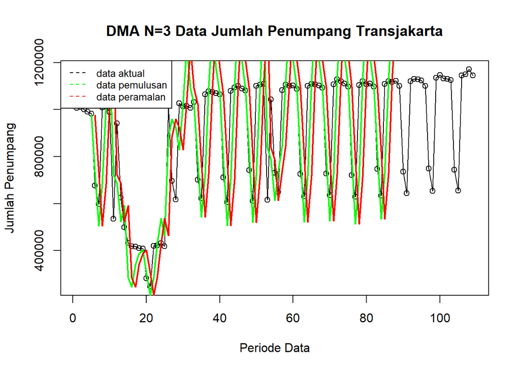

```r
ts.plot(data_mpdw.ts, xlab="Periode Data", ylab="Jumlah Penumpang", main= "DMA N=3 Data Jumlah Penumpang Transjakarta")
points(data_mpdw.ts)
lines(data_gab2[,3],col="green",lwd=2)
lines(data_gab2[,6],col="red",lwd=2)
legend("topleft",c("data aktual","data pemulusan","data peramalan"), lty=8, col=c("black","green","red"), cex=0.8)
```

Selanjutnya perhitungan akurasi dilakukan baik pada data latih maupun data uji. Perhitungan akurasi dilakukan dengan ukuran akurasi SSE, MSE dan MAPE.

```r
#menghitung akurasi data latih
error_train_dma = train_mpdw.ts-ramal_dma[1:length(train_mpdw.ts)]
SSE_train_dma = sum(error_train_dma[8:length(train_mpdw.ts)]^2)
MSE_train_dma = mean(error_train_dma[8:length(train_mpdw.ts)]^2)
MAPE_train_dma = mean(abs((error_train_dma[8:length(train_mpdw.ts)]/train_mpdw.ts[8:length(train_mpdw.ts)])*100))

akurasi_train_dma <- matrix(c(SSE_train_dma, MSE_train_dma, MAPE_train_dma))
row.names(akurasi_train_dma)<- c("SSE", "MSE", "MAPE")
colnames(akurasi_train_dma) <- c("Akurasi m = 3")
akurasi_train_dma
```

```
##      Akurasi m = 3
## SSE   7.602698e+12
## MSE   9.503373e+10
## MAPE  2.962339e+01
```

selanjutnya, kita akan menghitung akurasi pada data uji

```r
#menghitung akurasi data uji
error_test_dma = test_mpdw.ts-data_gab2[88:109,6]
SSE_test_dma = sum(error_test_dma^2)
MSE_test_dma = mean(error_test_dma^2)
MAPE_test_dma = mean(abs((error_test_dma/test_mpdw.ts*100)))

akurasi_test_dma <- matrix(c(SSE_test_dma, MSE_test_dma, MAPE_test_dma))
row.names(akurasi_test_dma)<- c("SSE", "MSE", "MAPE")
colnames(akurasi_test_dma) <- c("Akurasi m = 4")
akurasi_test_dma
```

```
##      Akurasi m = 4
## SSE   1.044244e+14
## MSE   4.746563e+12
## MAPE  2.056555e+02
```

## Single Exponential Smoothing & Double Exponential Smoothing

Metode *Exponential Smoothing* adalah metode pemulusan dengan melakukan pembobotan menurun secara eksponensial. Nilai yang lebih baru diberi bobot yang lebih besar dari nilai terdahulu. Terdapat satu atau lebih parameter pemulusan yang ditentukan secara eksplisit, dan hasil pemilihan parameter tersebut akan menentukan bobot yang akan diberikan pada nilai pengamatan. Ada dua macam model, yaitu model tunggal dan ganda.

### Pembagian Data

Pembagian data latih dan data uji dilakukan dengan perbandingan 80% data latih dan 20% data uji.

```r
#data 1 sampai 87 merupakan data training
train_mpdw <- data_mpdw[1:87,]
#merubah data training menjadi time series
train_mpdw.ts <- ts(train_mpdw$jumlah_penumpang_transjakarta)
train_mpdw.ts
```

```
## Time Series:
## Start = 1
## End = 87
## Frequency = 1
##  [1] 1006666 1011406 1000208  991508  982905  676818  597413 1008471 1011261
## [10]  989925  535537  941749  625534  498446  433517  418970  416837  409463
## [19]  408345  282422  246739  420126  422024  430748  417971 1015361  695963
## [28]  617558 1026591 1014345 1014851 1007231 1032009  700670  621726 1065550
## [37] 1078830 1074826 1070391 1064895  711037  605562 1080611 1094329 1101370
## [46] 1090495 1081846  742942  611442 1100966 1105993 1109120  615710 1043002
## [55]  730363  650239 1083284 1105891 1100992 1102279 1087623  725319  630556
## [64] 1100382 1109216 1107503 1103250 1093067  727497  635855 1107316 1128713
## [73] 1121625 1110376 1097821  721052  629687 1104758 1120393 1107625 1111359
## [82] 1097914  748153  633768 1109764 1121596 1117922
```

```r
#data 88 sampai 109 merupakan data testing
test_mpdw <- data_mpdw[88:109,]
#merubah data testing menjadi time series
test_mpdw.ts <- ts(test_mpdw$jumlah_penumpang_transjakarta)
```

### Single Exponential Smoothing (SES)

Single Exponential Smoothing merupakan metode pemulusan yang tepat digunakan untuk data dengan pola stasioner atau konstan.

Nilai pemulusan pada periode ke-t didapat dari persamaan:
$$\tilde{y}_T=\lambda y_t+(1-\lambda)\tilde{y}_{T-1}$$
Nilai parameter $\lambda$ adalah nilai antara 0 dan 1.

Nilai pemulusan periode ke-t bertindak sebagai nilai ramalan pada periode ke-$(T+\tau)$.

$$\tilde{y}_{T+\tau}(T)=\tilde{y}_T$$

Pemulusan dengan metode SES dapat dilakukan dengan dua fungsi dari *packages* berbeda, yaitu (1) fungsi `ses()` dari *packages* `forecast` dan (2) fungsi `HoltWinters` dari *packages* `stats` .

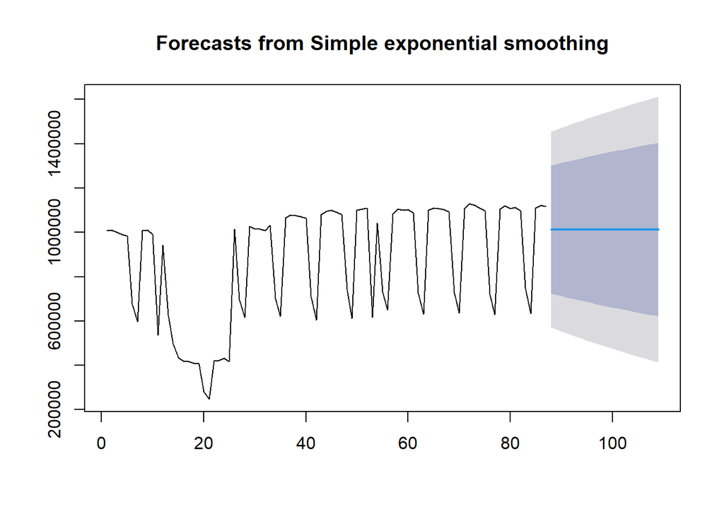

```r
#Cara 1 (fungsi ses)
ses.1 <- ses(train_mpdw.ts, h = 22, alpha = 0.2)
plot(ses.1)
```

```r
ses.1
```

```
##     Point Forecast    Lo 80   Hi 80    Lo 95   Hi 95
##  88        1012824 724044.9 1301603 571174.5 1454474
##  89        1012824 718326.0 1307322 562428.1 1463220
##  90        1012824 712716.0 1312932 553848.4 1471800
##  91        1012824 707209.0 1318439 545426.1 1480222
##  92        1012824 701799.4 1323849 537152.9 1488495
##  93        1012824 696482.4 1329166 529021.2 1496627
##  94        1012824 691253.2 1334395 521023.9 1504624
##  95        1012824 686107.8 1339540 513154.6 1512494
##  96        1012824 681042.1 1344606 505407.3 1520241
##  97        1012824 676052.6 1349596 497776.6 1527872
##  98        1012824 671136.0 1354512 490257.2 1535391
##  99        1012824 666289.1 1359359 482844.6 1542804
## 100        1012824 661509.1 1364139 475534.2 1550114
## 101        1012824 656793.2 1368855 468321.9 1557326
## 102        1012824 652139.1 1373509 461203.9 1564444
## 103        1012824 647544.2 1378104 454176.6 1571472
## 104        1012824 643006.3 1382642 447236.6 1578412
## 105        1012824 638523.5 1387125 440380.8 1585267
## 106        1012824 634093.8 1391554 433606.1 1592042
## 107        1012824 629715.3 1395933 426909.7 1598738
## 108        1012824 625386.2 1400262 420289.0 1605359
## 109        1012824 621105.0 1404543 413741.4 1611907
```

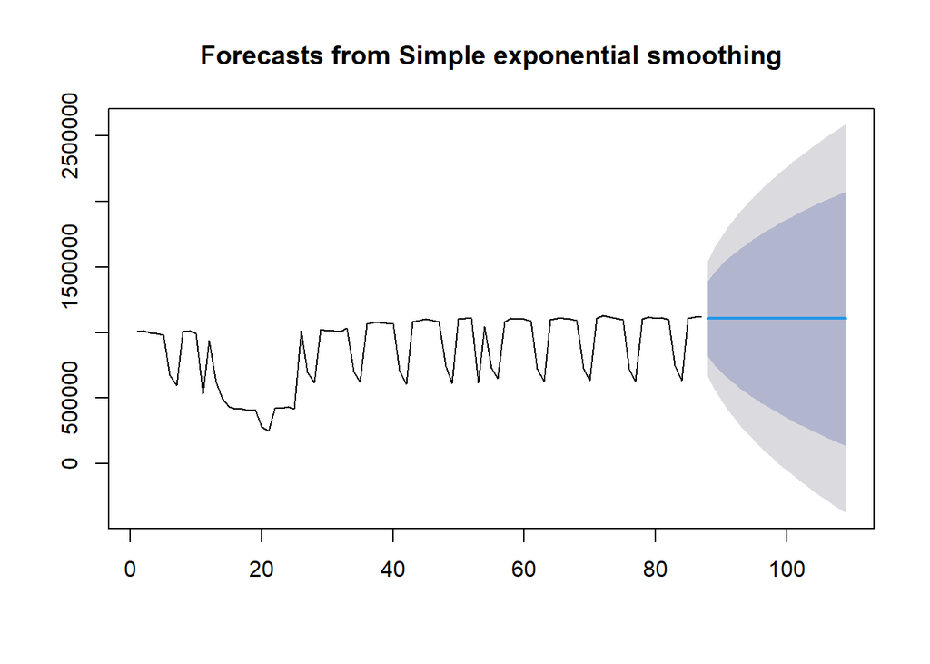

```r
ses.2<- ses(train_mpdw.ts, h = 22, alpha = 0.7)
plot(ses.2)
```

```r
ses.2
```

```
##     Point Forecast    Lo 80   Hi 80       Lo 95   Hi 95
##  88        1106891 818547.7 1395234  665907.980 1547874
##  89        1106891 754923.1 1458859  568602.637 1645179
##  90        1106891 701156.0 1512626  486372.912 1727409
##  91        1106891 653723.9 1560058  413831.816 1799950
##  92        1106891 610806.4 1602975  348195.168 1865587
##  93        1106891 571317.1 1642465  287801.445 1925980
##  94        1106891 534545.9 1679236  231564.757 1982217
##  95        1106891 499998.6 1713783  178729.180 2035053
##  96        1106891 467314.7 1746467  128743.417 2085038
##  97        1106891 436221.6 1777560   81190.738 2132591
##  98        1106891 406507.6 1807274   35747.052 2178035
##  99        1106891 378003.9 1835778   -7845.601 2221627
## 100        1106891 350573.7 1863208  -49796.520 2263578
## 101        1106891 324104.0 1889678  -90278.307 2304060
## 102        1106891 298500.7 1915281 -129435.284 2343217
## 103        1106891 273683.7 1940098 -167389.586 2381171
## 104        1106891 249584.8 1964197 -204245.660 2418028
## 105        1106891 226145.1 1987637 -240093.659 2453876
## 106        1106891 203313.2 2010469 -275012.036 2488794
## 107        1106891 181044.1 2032738 -309069.568 2522851
## 108        1106891 159298.3 2054484 -342326.948 2556109
## 109        1106891 138040.4 2075741 -374838.054 2588620
```

Untuk mendapatkan gambar hasil pemulusan pada data latih dengan fungsi `ses()` , perlu digunakan fungsi `autoplot()` dan `autolayer()` dari *library packages* `ggplot2` .

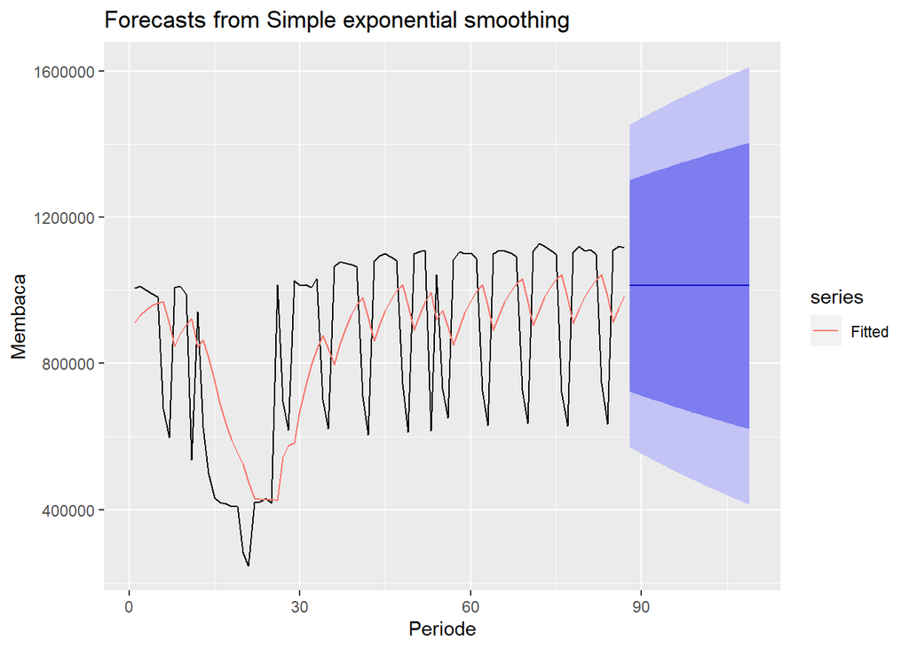

```r
autoplot(ses.1) +
  autolayer(fitted(ses.1), series="Fitted") +
  ylab("Membaca") + xlab("Periode")
```

Pada fungsi `ses()` , terdapat beberapa argumen yang umum digunakan, yaitu nilia `y` , `gamma` , `beta` , `alpha` , dan `h` .

Nilai `y` adalah nilai data deret waktu, `gamma` adalah parameter pemulusan untuk komponen musiman, `beta` adalah parameter pemulusan untuk tren, dan `alpha` adalah parameter pemulusan untuk stasioner, serta `h` adalah banyaknya periode yang akan diramalkan.

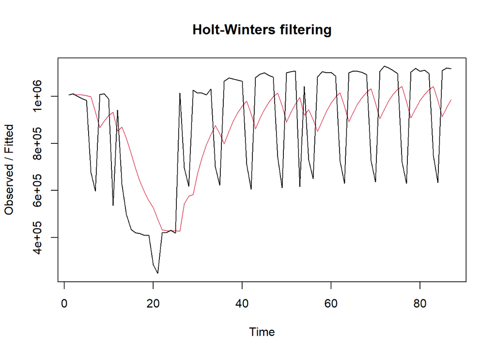

```r
#Cara 2 (fungsi Holtwinter)
ses1<- HoltWinters(train_mpdw.ts, gamma = FALSE, beta = FALSE, alpha = 0.2)
plot(ses1)
```

```r
#ramalan
ramalan1<- forecast(ses1, h=22)
ramalan1
```

```
##     Point Forecast    Lo 80   Hi 80    Lo 95   Hi 95
##  88        1012824 723230.4 1302418 569928.7 1455719
##  89        1012824 717495.3 1308153 561157.7 1464491
##  90        1012824 711869.5 1313779 552553.7 1473094
##  91        1012824 706346.9 1319301 544107.7 1481540
##  92        1012824 700922.1 1324726 535811.2 1489837
##  93        1012824 695590.1 1330058 527656.5 1497992
##  94        1012824 690346.2 1335302 519636.7 1506011
##  95        1012824 685186.2 1340462 511745.2 1513903
##  96        1012824 680106.3 1345542 503976.1 1521672
##  97        1012824 675102.7 1350545 496323.8 1529324
##  98        1012824 670172.2 1355476 488783.2 1536865
##  99        1012824 665311.6 1360337 481349.7 1544299
## 100        1012824 660518.1 1365130 474018.6 1551630
## 101        1012824 655789.0 1369859 466786.0 1558862
## 102        1012824 651121.7 1374527 459648.0 1566000
## 103        1012824 646513.8 1379134 452600.9 1573047
## 104        1012824 641963.2 1383685 445641.3 1580007
## 105        1012824 637467.7 1388180 438766.1 1586882
## 106        1012824 633025.5 1392623 431972.3 1593676
## 107        1012824 628634.6 1397014 425257.0 1600391
## 108        1012824 624293.4 1401355 418617.6 1607031
## 109        1012824 620000.1 1405648 412051.6 1613597
```

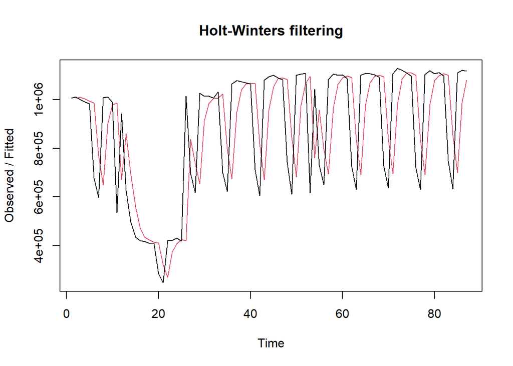

```r
ses2<- HoltWinters(train_mpdw.ts, gamma = FALSE, beta = FALSE, alpha = 0.7)
plot(ses2)
```

```r
#ramalan
ramalan2<- forecast(ses2, h=22)
ramalan2
```

```
##     Point Forecast    Lo 80   Hi 80       Lo 95   Hi 95
##  88        1106891 818555.7 1395226  665920.175 1547862
##  89        1106891 754932.9 1458849  568617.523 1645164
##  90        1106891 701167.2 1512615  486390.072 1727392
##  91        1106891 653736.5 1560045  413850.983 1799931
##  92        1106891 610820.2 1602962  348216.149 1865566
##  93        1106891 571331.9 1642450  287824.097 1925958
##  94        1106891 534561.7 1679220  231588.964 1982193
##  95        1106891 500015.4 1713767  178754.848 2035027
##  96        1106891 467332.3 1746450  128770.467 2085011
##  97        1106891 436240.2 1777542   81219.104 2132563
##  98        1106891 406527.0 1807255   35776.674 2178005
##  99        1106891 378024.1 1835758   -7814.773 2221597
## 100        1106891 350594.6 1863187  -49764.532 2263546
## 101        1106891 324125.7 1889656  -90245.200 2304027
## 102        1106891 298523.0 1915259 -129401.094 2343183
## 103        1106891 273706.7 1940075 -167354.346 2381136
## 104        1106891 249608.5 1964173 -204209.401 2417991
## 105        1106891 226169.4 1987612 -240056.408 2453838
## 106        1106891 203338.1 2010444 -274973.820 2488756
## 107        1106891 181069.7 2032712 -309030.410 2522812
## 108        1106891 159324.5 2054457 -342286.870 2556069
## 109        1106891 138067.2 2075715 -374797.077 2588579
```

Fungsi `HoltWinters` memiliki argumen yang sama dengan fungsi `ses()` . Argumen-argumen kedua fungsi dapat dilihat lebih lanjut dengan `?ses()` atau `?HoltWinters` .

Nilai parameter $\alpha$ dari kedua fungsi dapat dioptimalkan menyesuaikan dari *error*-nya paling minimumnya. Caranya adalah dengan membuat parameter $\alpha =$ `NULL` .

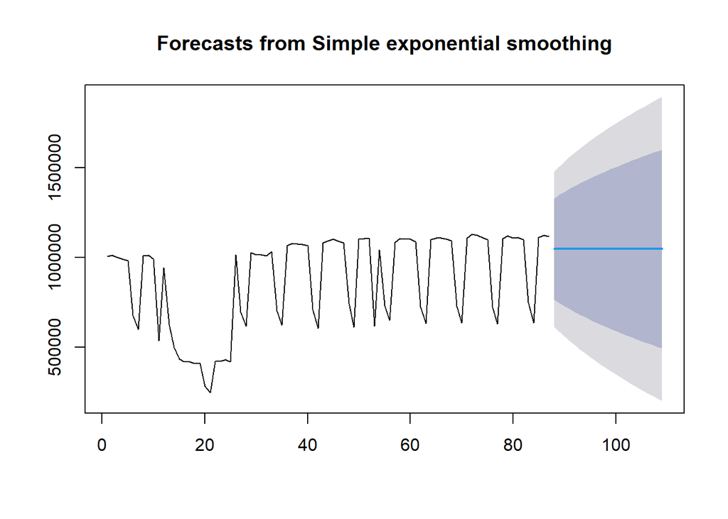

```r
#SES
ses.opt <- ses(train_mpdw.ts, h = 22, alpha = NULL)
plot(ses.opt)
```

```r
ses.opt
```

```
##     Point Forecast    Lo 80   Hi 80    Lo 95   Hi 95
##  88        1046803 764440.1 1329166 614966.1 1478640
##  89        1046803 745958.4 1347648 586700.7 1506906
##  90        1046803 728548.1 1365058 560074.0 1533532
##  91        1046803 712042.1 1381564 534830.3 1558776
##  92        1046803 696312.6 1397294 510774.0 1582832
##  93        1046803 681259.3 1412347 487752.0 1605854
##  94        1046803 666801.8 1426805 465641.2 1627965
##  95        1046803 652874.6 1440732 444341.4 1649265
##  96        1046803 639423.2 1454183 423769.3 1669837
##  97        1046803 626402.1 1467204 403855.1 1689751
##  98        1046803 613772.3 1479834 384539.5 1709067
##  99        1046803 601500.5 1492106 365771.5 1727835
## 100        1046803 589558.0 1504048 347507.0 1746099
## 101        1046803 577919.6 1515687 329707.5 1763899
## 102        1046803 566563.1 1527043 312339.3 1781267
## 103        1046803 555469.1 1538137 295372.5 1798234
## 104        1046803 544620.0 1548986 278780.3 1814826
## 105        1046803 534000.5 1559606 262539.1 1831067
## 106        1046803 523596.5 1570010 246627.5 1846979
## 107        1046803 513395.3 1580211 231026.2 1862580
## 108        1046803 503385.6 1590221 215717.7 1877889
## 109        1046803 493557.0 1600049 200686.1 1892920
```

```r
#Lamda Optimum Holt Winter
sesopt<- HoltWinters(train_mpdw.ts, gamma = FALSE, beta = FALSE,alpha = NULL)
sesopt
```

```
## Holt-Winters exponential smoothing without trend and without seasonal component.
##
## Call:
## HoltWinters(x = train_mpdw.ts, alpha = NULL, beta = FALSE, gamma = FALSE)
##
## Smoothing parameters:
##  alpha: 0.3740303
##  beta : FALSE
##  gamma: FALSE
##
## Coefficients:
##      [,1]
## a 1048196
```

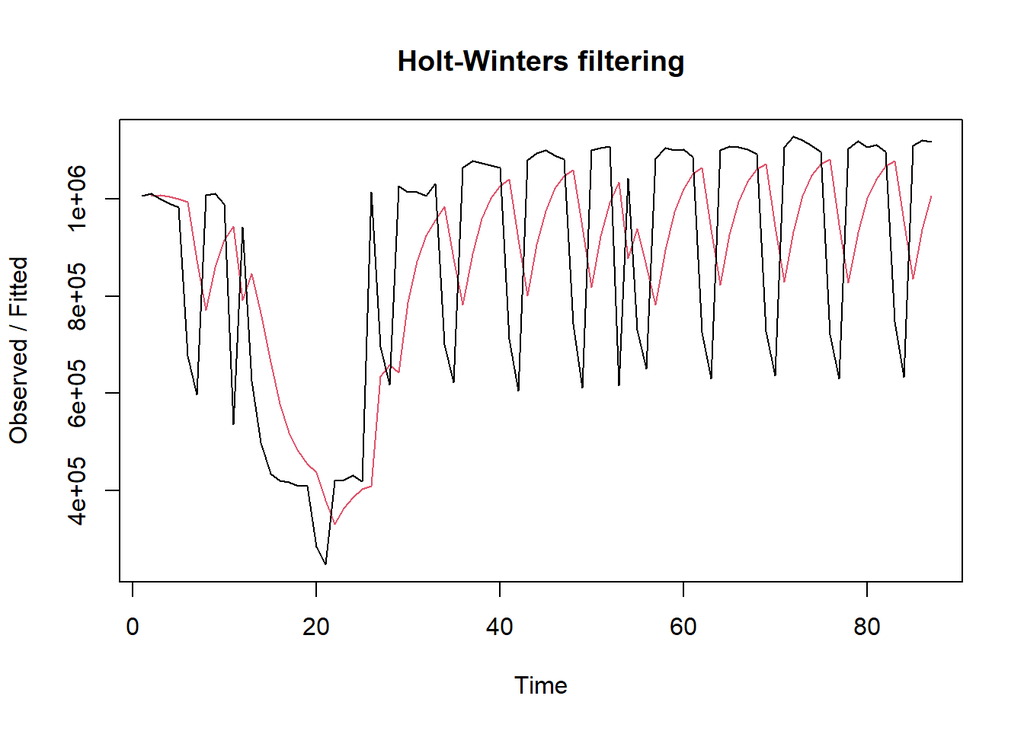

```r
plot(sesopt)
```

```r
#ramalan
ramalanopt<- forecast(sesopt, h=22)
ramalanopt
```

```
##     Point Forecast    Lo 80   Hi 80    Lo 95   Hi 95
##  88        1048196 765941.7 1330450 616525.5 1479866
##  89        1048196 746844.3 1349547 587318.5 1509073
##  90        1048196 728887.1 1367504 559855.3 1536536
##  91        1048196 711887.3 1384504 533856.4 1562535
##  92        1048196 695706.4 1400685 509109.8 1587282
##  93        1048196 680236.4 1416155 485450.5 1610941
##  94        1048196 665391.1 1431000 462746.5 1633645
##  95        1048196 651100.3 1445291 440890.7 1655501
##  96        1048196 637306.3 1459085 419794.6 1676597
##  97        1048196 623960.6 1472431 399384.0 1697007
##  98        1048196 611022.1 1485369 379596.3 1716795
##  99        1048196 598455.6 1497936 360377.6 1736014
## 100        1048196 586230.9 1510161 341681.5 1754710
## 101        1048196 574321.4 1522070 323467.5 1772924
## 102        1048196 562704.0 1533687 305700.2 1790691
## 103        1048196 551358.2 1545033 288348.2 1808043
## 104        1048196 540265.7 1556126 271383.8 1825008
## 105        1048196 529410.3 1566981 254781.9 1841610
## 106        1048196 518777.5 1577614 238520.5 1857871
## 107        1048196 508354.1 1588037 222579.2 1873812
## 108        1048196 498128.2 1598263 206940.0 1889452
## 109        1048196 488088.9 1608303 191586.2 1904805
```

Setelah dilakukan peramalan, akan dilakukan perhitungan keakuratan hasil peramalan. Perhitungan akurasi ini dilakukan baik pada data latih dan data uji.

#### Akurasi Data Latih

Perhitungan akurasi data dapat dilakukan dengan cara langsung maupun manual. Secara langsung, nilai akurasi dapat diambil dari objek yang tersimpan pada hasil SES, yaitu *sum of squared errors* (SSE). Nilai akurasi lain dapat dihitung pula dari nilai SSE tersebut.

```r
#Keakuratan Metode
#Pada data training
SSE1<-ses1$SSE
MSE1<-ses1$SSE/length(train_mpdw.ts)
RMSE1<-sqrt(MSE1)

akurasi1 <- matrix(c(SSE1,MSE1,RMSE1))
row.names(akurasi1)<- c("SSE", "MSE", "RMSE")
colnames(akurasi1) <- c("Akurasi lamda=0.2")
akurasi1
```

```
##      Akurasi lamda=0.2
## SSE       4.340364e+12
## MSE       4.988924e+10
## RMSE      2.233590e+05
```

```r
SSE2<-ses2$SSE
MSE2<-ses2$SSE/length(train_mpdw.ts)
RMSE2<-sqrt(MSE2)

akurasi2 <- matrix(c(SSE2,MSE2,RMSE2))
row.names(akurasi2)<- c("SSE", "MSE", "RMSE")
colnames(akurasi2) <- c("Akurasi lamda=0.7")
akurasi2
```

```
##      Akurasi lamda=0.7
## SSE       4.302951e+12
## MSE       4.945921e+10
## RMSE      2.223943e+05
```

```r
#Cara Manual
fitted1<-ramalan1$fitted
sisaan1<-ramalan1$residuals
head(sisaan1)
```

```
## Time Series:
## Start = 1
## End = 6
## Frequency = 1
## [1]         NA    4740.00   -7406.00  -14624.80  -20302.84 -322329.27
```

```r
resid1<-train_mpdw$jumlah_penumpang_transjakarta-ramalan1$fitted
head(resid1)
```

```
## Time Series:
## Start = 1
## End = 6
## Frequency = 1
## [1]         NA    4740.00   -7406.00  -14624.80  -20302.84 -322329.27
```

```r
#Cara Manual
SSE.1=sum(sisaan1[2:length(train_mpdw.ts)]^2)
SSE.1
```

```
## [1] 4.340364e+12
```

```r
MSE.1 = SSE.1/length(train_mpdw.ts)
MSE.1
```

```
## [1] 49889235837
```

```r
MAPE.1 = sum(abs(sisaan1[2:length(train_mpdw.ts)]/train_mpdw.ts[2:length(train_mpdw.ts)])*
               100)/length(train_mpdw.ts)
MAPE.1
```

```
## [1] 26.42646
```

```r
akurasi.1 <- matrix(c(SSE.1,MSE.1,MAPE.1))
row.names(akurasi.1)<- c("SSE", "MSE", "MAPE")
colnames(akurasi.1) <- c("Akurasi lamda=0.2")
akurasi.1
```

```
##      Akurasi lamda=0.2
## SSE       4.340364e+12
## MSE       4.988924e+10
## MAPE      2.642646e+01
```

```r
fitted2<-ramalan2$fitted
sisaan2<-ramalan2$residuals
head(sisaan2)
```

```
## Time Series:
## Start = 1
## End = 6
## Frequency = 1
## [1]         NA    4740.00   -9776.00  -11632.80  -12092.84 -309714.85
```

```r
resid2<-train_mpdw$jumlah_penumpang_transjakarta-ramalan2$fitted
head(resid2)
```

```
## Time Series:
## Start = 1
## End = 6
## Frequency = 1
## [1]         NA    4740.00   -9776.00  -11632.80  -12092.84 -309714.85
```

```r
SSE.2=sum(sisaan2[2:length(train_mpdw.ts)]^2)
SSE.2
```

```
## [1] 4.302951e+12
```

```r
MSE.2 = SSE.2/length(train_mpdw.ts)
MSE.2
```

```
## [1] 49459206639
```

```r
MAPE.2 = sum(abs(sisaan2[2:length(train_mpdw.ts)]/train_mpdw.ts[2:length(train_mpdw.ts)])*
               100)/length(train_mpdw.ts)
MAPE.2
```

```
## [1] 20.8264
```

```r
akurasi.2 <- matrix(c(SSE.2,MSE.2,MAPE.2))
row.names(akurasi.2)<- c("SSE", "MSE", "MAPE")
colnames(akurasi.2) <- c("Akurasi lamda=0.7")
akurasi.2
```

```
##      Akurasi lamda=0.7
## SSE       4.302951e+12
## MSE       4.945921e+10
## MAPE      2.082640e+01
```

#### Akurasi Data Uji

Akurasi data uji dapat dihitung dengan cara yang hampir sama dengan perhitungan akurasi data latih.

```r
selisih1<-ramalan1$mean - test_mpdw$jumlah_penumpang_transjakarta
ramalan1
```

```
##     Point Forecast    Lo 80   Hi 80    Lo 95   Hi 95
##  88        1012824 723230.4 1302418 569928.7 1455719
##  89        1012824 717495.3 1308153 561157.7 1464491
##  90        1012824 711869.5 1313779 552553.7 1473094
##  91        1012824 706346.9 1319301 544107.7 1481540
##  92        1012824 700922.1 1324726 535811.2 1489837
##  93        1012824 695590.1 1330058 527656.5 1497992
##  94        1012824 690346.2 1335302 519636.7 1506011
##  95        1012824 685186.2 1340462 511745.2 1513903
##  96        1012824 680106.3 1345542 503976.1 1521672
##  97        1012824 675102.7 1350545 496323.8 1529324
##  98        1012824 670172.2 1355476 488783.2 1536865
##  99        1012824 665311.6 1360337 481349.7 1544299
## 100        1012824 660518.1 1365130 474018.6 1551630
## 101        1012824 655789.0 1369859 466786.0 1558862
## 102        1012824 651121.7 1374527 459648.0 1566000
## 103        1012824 646513.8 1379134 452600.9 1573047
## 104        1012824 641963.2 1383685 445641.3 1580007
## 105        1012824 637467.7 1388180 438766.1 1586882
## 106        1012824 633025.5 1392623 431972.3 1593676
## 107        1012824 628634.6 1397014 425257.0 1600391
## 108        1012824 624293.4 1401355 418617.6 1607031
## 109        1012824 620000.1 1405648 412051.6 1613597
```

```r
SSEtesting1<-sum(selisih1^2)
MSEtesting1<-SSEtesting1/length(test_mpdw)


selisih2<-ramalan2$mean - test_mpdw$jumlah_penumpang_transjakarta
SSEtesting2<-sum(selisih2^2)
MSEtesting2<-SSEtesting2/length(test_mpdw)

selisihopt<-ramalanopt$mean-test_mpdw$jumlah_penumpang_transjakarta
SSEtestingopt<-sum(selisihopt^2)
MSEtestingopt<-SSEtestingopt/length(test_mpdw)

akurasitesting1 <- matrix(c(SSEtesting1,SSEtesting2,SSEtestingopt))
row.names(akurasitesting1)<- c("SSE1", "SSE2", "SSEopt")
akurasitesting1
```

```
##                [,1]
## SSE1   8.455043e+11
## SSE2   1.037908e+12
## SSEopt 8.721781e+11
```

```r
akurasitesting2 <- matrix(c(MSEtesting1,MSEtesting2,MSEtestingopt))
row.names(akurasitesting2)<- c("MSE1", "MSE2", "MSEopt")
akurasitesting2
```

```
##                [,1]
## MSE1   422752170269
## MSE2   518954085260
## MSEopt 436089060852
```

Selain dengan cara di atas, perhitungan nilai akurasi dapat menggunakan fungsi `accuracy()` dari *package* `forecast` . Penggunaannya yaitu dengan menuliskan `accuracy(hasil ramalan, kondisi aktual)` . Contohnya adalah sebagai berikut.

```r
#cara lain
accuracy(ramalanopt,test_mpdw$jumlah_penumpang_transjakarta)
```

```
##                      ME     RMSE      MAE       MPE     MAPE     MASE      ACF1
## Training set   1291.083 218963.5 182050.8 -6.351831 24.23009 1.247819 0.2054732
## Test set     -34824.474 199109.2 156962.8 -8.570933 19.32867 1.075860        NA
```

### DES

Metode pemulusan *Double Exponential Smoothing* (DES) digunakan untuk data yang memiliki pola tren. Metode DES adalah metode semacam SES, hanya saja dilakukan dua kali, yaitu pertama untuk tahapan ‘level’ dan kedua untuk tahapan ‘tren’. Pemulusan menggunakan metode ini akan menghasilkan peramalan tidak konstan untuk periode berikutnya.

Pemulusan dengan metode DES kali ini akan menggunakan fungsi `HoltWinters()` . Jika sebelumnya nilai argumen `beta` dibuat `FALSE` , kali ini argumen tersebut akan diinisialisasi bersamaan dengan nilai `alpha` .

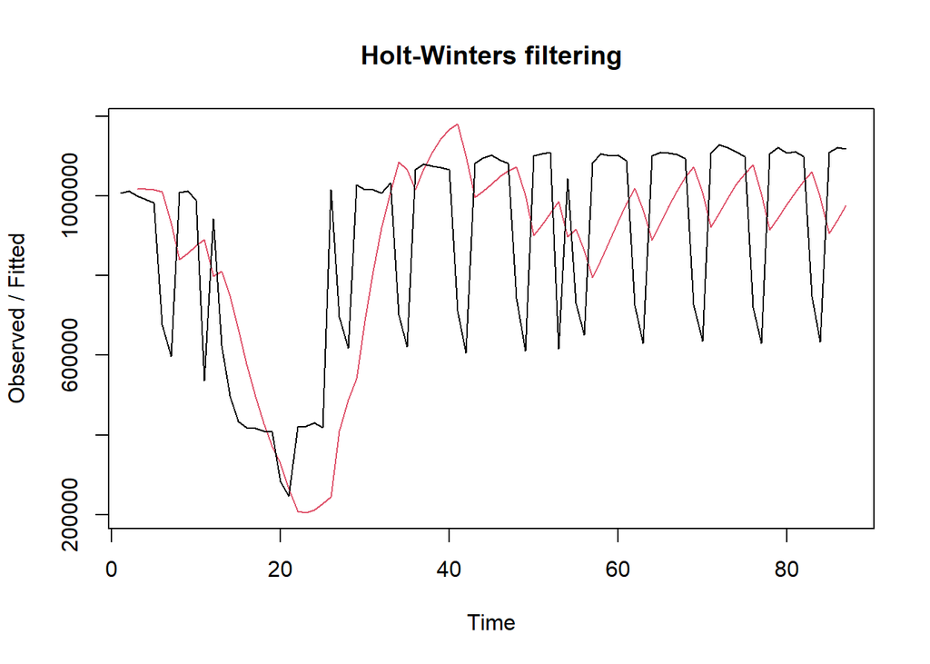

```r
#Lamda=0.2 dan gamma=0.2
des.1<- HoltWinters(train_mpdw.ts, gamma = FALSE, beta = 0.2, alpha = 0.2)
plot(des.1)
```

```r
#ramalan
ramalandes1<- forecast(des.1, h=22)
ramalandes1
```

```
##     Point Forecast     Lo 80   Hi 80      Lo 95   Hi 95
##  88        1007986 698084.97 1317888  534033.11 1481940
##  89        1012765 694063.87 1331467  525353.46 1500177
##  90        1017545 687241.45 1347848  512389.56 1522700
##  91        1022324 677454.82 1367192  494892.29 1549755
##  92        1027103 664637.39 1389568  472759.82 1581446
##  93        1031882 648805.69 1414958  446017.41 1617746
##  94        1036661 630040.17 1443282  414788.12 1658534
##  95        1041440 608464.53 1474416  379261.12 1703619
##  96        1046219 584227.05 1508211  339663.19 1752775
##  97        1050998 557485.87 1544511  296236.18 1805760
##  98        1055777 528398.51 1583156  249220.99 1862334
##  99        1060557 497115.29 1623998  198847.53 1922265
## 100        1065336 463775.67 1666896  145329.07 1985342
## 101        1070115 428506.66 1711723   88859.87 2051370
## 102        1074894 391422.59 1758365   29614.77 2120173
## 103        1079673 352625.62 1806720  -32249.98 2191596
## 104        1084452 312206.75 1856697  -96595.23 2265499
## 105        1089231 270246.85 1908215 -163297.25 2341760
## 106        1094010 226817.92 1961203 -232245.98 2420267
## 107        1098789 181984.07 2015595 -303343.34 2500922
## 108        1103568 135802.59 2071334 -376501.72 2583639
## 109        1108348  88324.83 2128370 -451642.60 2668338
```

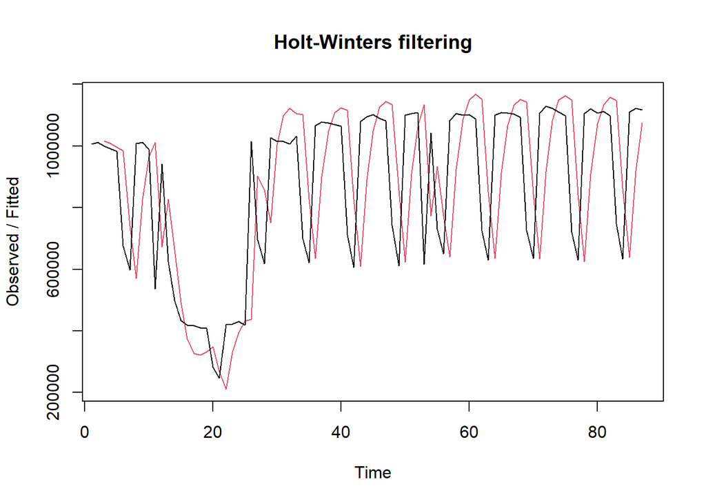

```r
#Lamda=0.6 dan gamma=0.3
des.2<- HoltWinters(train_mpdw.ts, gamma = FALSE, beta = 0.3, alpha = 0.6)
plot(des.2)
```

```r
#ramalan
ramalandes2<- forecast(des.2, h=22)
ramalandes2
```

```
##     Point Forecast       Lo 80   Hi 80       Lo 95   Hi 95
##  88        1142979   820019.04 1465939   649054.42 1636903
##  89        1185139   775553.06 1594726   558731.10 1811548
##  90        1227300   713601.01 1740999   441665.14 2012935
##  91        1269461   637448.82 1901473   302881.94 2236039
##  92        1311621   549271.86 2073971   145708.44 2477534
##  93        1353782   450533.01 2257031   -27618.07 2735182
##  94        1395943   342261.56 2449623  -215523.44 3007408
##  95        1438103   225217.95 2650988  -416844.67 3293051
##  96        1480264    99989.09 2860538  -630684.17 3591212
##  97        1522424   -32955.15 3077804  -856323.30 3901172
##  98        1564585  -173227.19 3302397 -1093169.35 4222339
##  99        1606746  -320499.62 3533991 -1340721.57 4554213
## 100        1648906  -474490.41 3772303 -1598548.64 4896361
## 101        1691067  -634952.79 4017086 -1866273.15 5248407
## 102        1733227  -801668.04 4268123 -2143560.60 5610015
## 103        1775388  -974440.23 4525216 -2430111.33 5980887
## 104        1817549 -1153092.26 4788189 -2725654.51 6360752
## 105        1859709 -1337462.87 5056881 -3029943.50 6749362
## 106        1901870 -1527404.25 5331144 -3342752.25 7146492
## 107        1944030 -1722780.17 5610841 -3663872.41 7551933
## 108        1986191 -1923464.46 5895846 -3993111.02 7965493
## 109        2028352 -2129339.77 6186043 -4330288.61 8386992
```

Selanjutnya jika ingin membandingkan plot data latih dan data uji adalah sebagai berikut.

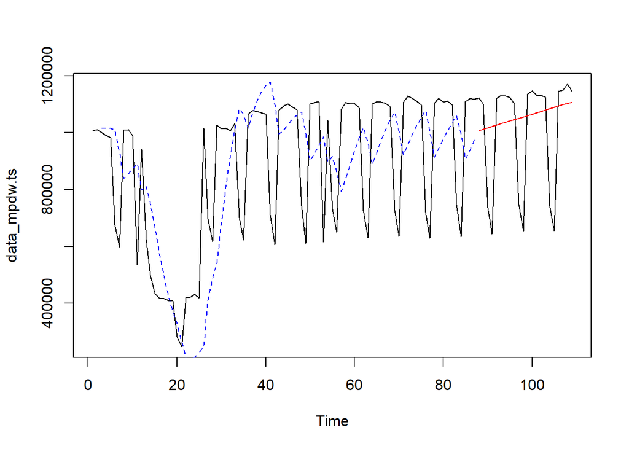

```r
#Visually evaluate the prediction
plot(data_mpdw.ts)
lines(des.1$fitted[,1], lty=2, col="blue")
lines(ramalandes1$mean, col="red")
```

Untuk mendapatkan nilai parameter optimum dari DES, argumen `alpha` dan `beta` dapat dibuat `NULL` seperti berikut.

```r
#Lamda dan gamma optimum
des.opt<- HoltWinters(train_mpdw.ts, gamma = FALSE)
des.opt
```

```
## Holt-Winters exponential smoothing with trend and without seasonal component.
##
## Call:
## HoltWinters(x = train_mpdw.ts, gamma = FALSE)
##
## Smoothing parameters:
##  alpha: 0.3816088
##  beta : 0
##  gamma: FALSE
##
## Coefficients:
##      [,1]
## a 1057542
## b    4740
```

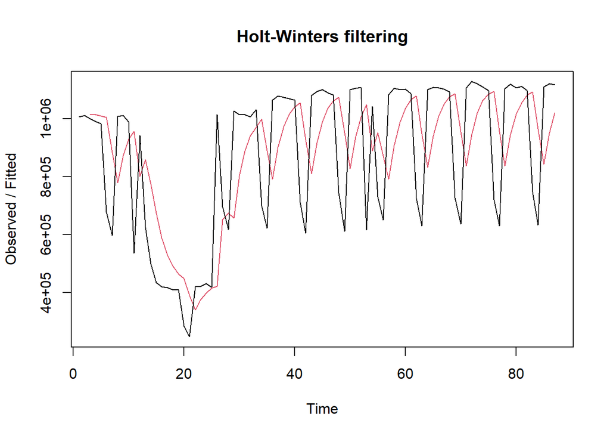

```r
plot(des.opt)
```

```r
#ramalan
ramalandesopt<- forecast(des.opt, h=22)
ramalandesopt
```

```
##     Point Forecast    Lo 80   Hi 80    Lo 95   Hi 95
##  88        1062282 778384.7 1346180 628098.5 1496466
##  89        1067022 763155.7 1370889 602298.5 1531746
##  90        1071762 749160.4 1394364 578385.4 1565139
##  91        1076502 736195.0 1416809 556047.3 1596957
##  92        1081242 724106.3 1438378 535050.0 1627434
##  93        1085982 712775.7 1459189 515212.1 1656752
##  94        1090722 702109.0 1479335 496389.7 1685055
##  95        1095462 692030.4 1498894 478466.5 1712458
##  96        1100202 682477.0 1517927 461346.7 1739058
##  97        1104942 673396.8 1536487 444950.6 1764934
##  98        1109682 664745.7 1554619 429210.6 1790154
##  99        1114422 656486.0 1572358 414069.3 1814775
## 100        1119162 648585.3 1589739 399477.0 1838847
## 101        1123902 641015.4 1606789 385390.6 1862414
## 102        1128642 633751.6 1623533 371772.3 1885512
## 103        1133382 626772.1 1639992 358588.9 1908175
## 104        1138122 620057.7 1656187 345810.9 1930433
## 105        1142862 613591.1 1672133 333411.9 1952312
## 106        1147602 607356.9 1687847 321368.3 1973836
## 107        1152342 601341.2 1703343 309659.0 1995025
## 108        1157082 595531.5 1718633 298264.6 2015900
## 109        1161822 589916.4 1733728 287167.9 2036476
```

Selanjutnya akan dilakukan perhitungan akurasi pada data latih maupun data uji dengan ukuran akurasi SSE, MSE dan MAPE.

#### Akurasi Data Latih

```r
#Akurasi Data Training
ssedes.train1<-des.1$SSE
msedes.train1<-ssedes.train1/length(train_mpdw.ts)
sisaandes1<-ramalandes1$residuals
head(sisaandes1)
```

```
## Time Series:
## Start = 1
## End = 6
## Frequency = 1
## [1]         NA         NA  -15938.00  -25552.88  -32125.67 -333582.87
```

```r
mapedes.train1 <- sum(abs(sisaandes1[3:length(train_mpdw.ts)]/train_mpdw.ts[3:length(train_mpdw.ts)])
                      *100)/length(train_mpdw.ts)

akurasides.1 <- matrix(c(ssedes.train1,msedes.train1,mapedes.train1))
row.names(akurasides.1)<- c("SSE", "MSE", "MAPE")
colnames(akurasides.1) <- c("Akurasi lamda=0.2 dan gamma=0.2")
akurasides.1
```

```
##      Akurasi lamda=0.2 dan gamma=0.2
## SSE                     4.911951e+12
## MSE                     5.645921e+10
## MAPE                    2.590110e+01
```

```r
ssedes.train2<-des.2$SSE
msedes.train2<-ssedes.train2/length(train_mpdw.ts)
sisaandes2<-ramalandes2$residuals
head(sisaandes2)
```

```
## Time Series:
## Start = 1
## End = 6
## Frequency = 1
## [1]         NA         NA  -15938.00  -16946.36  -14202.36 -308032.33
```

```r
mapedes.train2 <- sum(abs(sisaandes2[3:length(train_mpdw.ts)]/train_mpdw.ts[3:length(train_mpdw.ts)])
                      *100)/length(train_mpdw.ts)

akurasides.2 <- matrix(c(ssedes.train2,msedes.train2,mapedes.train2))
row.names(akurasides.2)<- c("SSE", "MSE", "MAPE")
colnames(akurasides.2) <- c("Akurasi lamda=0.6 dan gamma=0.3")
akurasides.2
```

```
##      Akurasi lamda=0.6 dan gamma=0.3
## SSE                     5.335137e+12
## MSE                     6.132341e+10
## MAPE                    2.377371e+01
```

#### Akurasi Data Uji

```r
#Akurasi Data Testing
selisihdes1<-ramalandes1$mean-test_mpdw$jumlah_penumpang_transjakarta
selisihdes1
```

```
## Time Series:
## Start = 88
## End = 109
## Frequency = 1
##  [1] -113824.68  -89203.57  282465.54  379402.65  -93925.25  -98299.14
##  [7]  -92295.03  -82566.92  -55510.81  302424.29  401974.40  -74807.49
## [13]  -81206.38  -62576.27  -56547.17  -46442.06  339884.05  434662.16
## [19]  -52373.73  -51014.62  -67719.52  -36995.41
```

```r
SSEtestingdes1<-sum(selisihdes1^2)
MSEtestingdes1<-SSEtestingdes1/length(test_mpdw$jumlah_penumpang_transjakarta)
MAPEtestingdes1<-sum(abs(selisihdes1/test_mpdw$jumlah_penumpang_transjakarta)*100)/length(test_mpdw$jumlah_penumpang_transjakarta)

selisihdes2<-ramalandes2$mean-test_mpdw$jumlah_penumpang_transjakarta
selisihdes2
```

```
## Time Series:
## Start = 88
## End = 109
## Frequency = 1
##  [1]   21167.89   83170.49  492221.09  626539.70  190593.30  223600.90
##  [7]  266986.51  314096.11  378533.71  773850.31  910781.92  471381.52
## [13]  502364.12  558375.73  601786.33  649272.93 1072980.53 1205140.14
## [19]  755485.74  794226.34  814902.94  883008.55
```

```r
SSEtestingdes2<-sum(selisihdes2^2)
MSEtestingdes2<-SSEtestingdes2/length(test_mpdw$jumlah_penumpang_transjakarta*100)/length(test_mpdw$jumlah_penumpang_transjakarta)
MAPEtestingdes2<-sum(abs(selisihdes2/test_mpdw$jumlah_penumpang_transjakarta)*100)/length(test_mpdw$jumlah_penumpang_transjakarta)

selisihdesopt<-ramalandesopt$mean-test_mpdw$jumlah_penumpang_transjakarta
selisihdesopt
```

```
## Time Series:
## Start = 88
## End = 109
## Frequency = 1
##  [1] -59528.878 -34946.878 336683.122 433581.122 -39785.878 -44198.878
##  [7] -38233.878 -28544.878  -1527.878 356368.122 455879.122 -20941.878
## [13] -27379.878  -8788.878  -2798.878   7267.122 393554.122 488293.122
## [19]   1218.122   2538.122 -14205.878  16479.122
```

```r
SSEtestingdesopt<-sum(selisihdesopt^2)
MSEtestingdesopt<-SSEtestingdesopt/length(test_mpdw$jumlah_penumpang_transjakarta)
MAPEtestingdesopt<-sum(abs(selisihdesopt/test_mpdw$jumlah_penumpang_transjakarta)*100)/length(test_mpdw$jumlah_penumpang_transjakarta)

akurasitestingdes <-
  matrix(c(SSEtestingdes1,MSEtestingdes1,MAPEtestingdes1,SSEtestingdes2,MSEtestingdes2,
           MAPEtestingdes2,SSEtestingdesopt,MSEtestingdesopt,MAPEtestingdesopt),
         nrow=3,ncol=3)
row.names(akurasitestingdes)<- c("SSE", "MSE", "MAPE")
colnames(akurasitestingdes) <- c("des ske1","des ske2","des opt")
akurasitestingdes
```

```
##          des ske1     des ske2      des opt
## SSE  8.718055e+11 9.289147e+12 1.041875e+12
## MSE  3.962752e+10 1.919245e+10 4.735795e+10
## MAPE 1.879939e+01 6.339120e+01 1.767781e+01
```

#### Perbandingan SES dan DES

```r
MSEfull <-
  matrix(c(MSEtesting1,MSEtesting2,MSEtestingopt,MSEtestingdes1,MSEtestingdes2,
           MSEtestingdesopt),nrow=3,ncol=2)
row.names(MSEfull)<- c("ske 1", "ske 2", "ske opt")
colnames(MSEfull) <- c("ses","des")
MSEfull
```

```
##                  ses         des
## ske 1   422752170269 39627521565
## ske 2   518954085260 19192452488
## ske opt 436089060852 47357952368
```

Kedua metode dapat dibandingkan dengan menggunakan ukuran akurasi yang sama. Contoh di atas adalah perbandingan kedua metode dengan ukuran akurasi MSE. Hasilnya didapatkan metode DES lebih baik dibandingkan metode SES dilihat dari MSE yang lebih kecil nilainya.

## Pemulusan Data Musiman

Pertama impor kembali data baru untuk latihan data musiman.

```r
#Import data
library(rio)
data_mpdw <- read.csv("D:\\IPB\\Statistika Sem 5\\MPDW (Deret Waktu)\\Data Jumlah Penumpang Transjakarta Harian Tahun 2023-2024.csv", sep =";")
head(data_mpdw)
```

```
##   periode_data jumlah_penumpang_transjakarta tanggal X
## 1   01/01/2023                        363250       1
## 2   02/01/2023                        730984       2
## 3   03/01/2023                        783228       3
## 4   04/01/2023                        798449       4
## 5   05/01/2023                        807905       5
## 6   06/01/2023                        807617       6
```

Selanjutnya melakukan pembagian data dan mengubahnya menjadi data deret waktu.

```r
#ambil baris ke-219 sampai 327 dan kolom 1 sampai 2
data_mpdw <- data_mpdw[219:327,1:2]

#merubah kolom periode data menjadi angka berurut
data_mpdw$periode_data <- 1:nrow(data_mpdw)

#data 1 sampai 87 merupakan data training
train_mpdw <- data_mpdw[1:87,2]
#merubah data training menjadi time series
train_mpdw.ts <- ts(train_mpdw, frequency = 7)

#data 88 sampai 109 merupakan data testing
test_mpdw <- data_mpdw[88:109,2]
#merubah data testing menjadi time series
test_mpdw.ts <- ts(test_mpdw, frequency = 7)
```

Kemudian akan dilakukan eskplorasi dengan plot data deret waktu sebagai berikut.

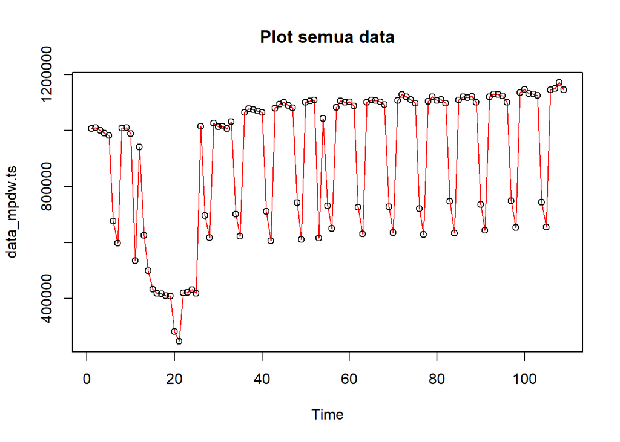

```r
#Membuat plot time series
plot(data_mpdw.ts, col="red",main="Plot semua data")
points(data_mpdw.ts)
```

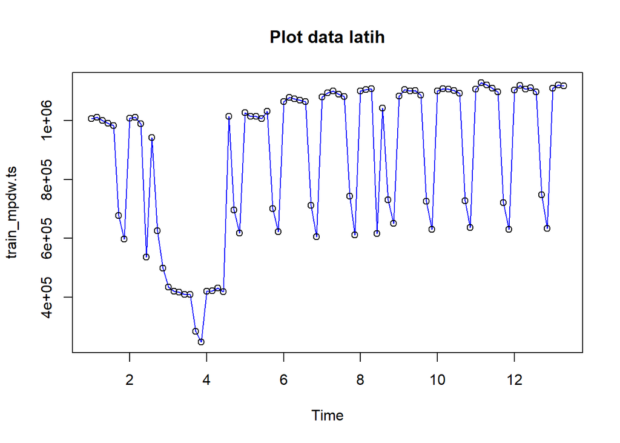

```r
plot(train_mpdw.ts, col="blue",main="Plot data latih")
points(train_mpdw.ts)
```

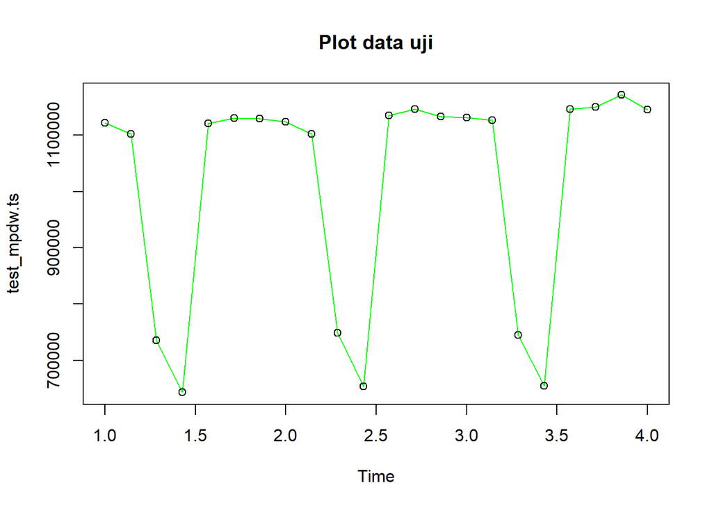

```r
plot(test_mpdw.ts, col="green",main="Plot data uji")
points(test_mpdw.ts)
```

Metode Holt-Winter untuk peramalan data musiman menggunakan tiga persamaan pemulusan yang terdiri atas persamaan untuk level $(L_t)$, trend $(B_t)$, dan komponen seasonal / musiman $(S_t)$ dengan parameter pemulusan berupa $\alpha$, $\beta$, dan $\gamma$. Metode Holt-Winter musiman terbagi menjadi dua, yaitu metode aditif dan metode multiplikatif. Perbedaan persamaan dan contoh datanya adalah sebagai berikut.

[figure not shown]

Pemulusan data musiman dengan metode Winter dilakukan menggunakan fungsi `HoltWinters()` dengan memasukkan argumen tambahan, yaitu `gamma()` dan `seasonal()` . Arguman `seasonal()` diinisialisasi menyesuaikan jenis musiman, aditif atau multiplikatif.

### Winter Aditif

Perhitungan dengan model aditif dilakukan jika plot data asli menunjukkan fluktuasi musiman yang relatif stabil (konstan).

#### Pemulusan

```r
#Pemulusan dengan winter aditif
winter1 <- HoltWinters(train_mpdw.ts,alpha=0.2,beta=0.1,gamma=0.1,seasonal = "additive")
winter1$fitted
```

```
## Time Series:
## Start = c(2, 1)
## End = c(13, 3)
## Frequency = 7
##                 xhat     level        trend      season
##  2.000000 1087332.13  927860.2 -15925.85544  175397.796
##  2.142857 1062726.25  896162.1 -17503.07803  184067.224
##  2.285714 1019891.11  868366.0 -18532.38311  170057.510
##  2.428571  735644.61  843840.4 -19131.70522  -89064.061
##  2.571429  844756.66  784687.1 -23133.85738   83203.367
##  2.714286  536894.83  780951.8 -21194.01053 -222862.918
##  2.857143  457265.44  777485.6 -19421.22713 -300798.918
##  3.000000  916791.76  766300.5 -18597.61586  169088.906
##  3.142857  802734.79  651047.9 -28263.11101  179950.004
##  3.285714  677753.65  546031.8 -35938.40688  167660.222
##  3.428571  311680.69  457910.1 -41156.73979 -105072.670
##  3.571429  488071.48  436309.8 -39201.09349   90962.755
##  3.714286  124596.02  381163.4 -40795.62308 -215771.785
##  3.857143   36789.42  371933.0 -37639.10349 -297504.473
##  4.000000  473270.63  376283.8 -33440.11198  130426.925
##  4.142857  446960.59  332214.8 -34503.00450  149248.821
##  4.285714  404509.61  292724.5 -35001.73634  146786.890
##  4.428571  131243.34  262970.4 -34476.96847  -97250.085
##  4.571429  341681.18  285839.0 -28742.41531   84584.636
##  4.714286  173417.98  391832.5 -15268.81890 -203145.706
##  4.857143  195546.27  481072.7  -4817.91854 -280708.507
##  5.000000  690454.79  560657.1   3622.31614  126175.355
##  5.142857  789105.61  631506.7  10345.04032  147253.893
##  5.285714  850635.39  686899.6  14849.82808  148885.962
##  5.428571  678414.82  734592.5  18134.14037  -74311.872
##  5.571429  981679.41  818489.9  24710.46406  138479.022
##  5.714286  717641.26  853266.3  25717.05586 -161342.105
##  5.857143  654019.17  875589.1  25377.63071 -246947.569
##  6.000000 1072306.13  894508.1  24731.76726  153066.252
##  6.142857 1107758.34  917888.6  24596.64474  165273.044
##  6.285714 1122740.91  936699.6  24018.07798  162023.211
##  6.428571  926187.92  951134.7  23059.77969  -48006.577
##  6.571429 1171484.35 1003035.1  25943.84122  142505.389
##  6.714286  868773.34 1007661.1  23812.05429 -162699.806
##  6.857143  771052.18  999925.9  20657.32755 -249531.022
```

[output cut: 30 more lines]

```
## 11.285714 1124325.85  971612.2   1006.91050  151706.710
## 11.428571  950708.42  972079.0    952.89346  -22323.443
## 11.571429 1130872.24 1004965.4   4146.24503  121760.613
## 11.714286  808693.42 1002501.4   3485.22027 -197293.177
## 11.857143  705233.60  988458.3   1732.39185 -284957.106
## 12.000000 1118838.91  975081.4    221.45986  143536.063
## 12.142857 1127727.91  972486.7    -60.15831  155301.404
## 12.285714 1122243.31  970959.5   -206.85649  151490.642
## 12.428571  957779.75  967829.0   -499.22268   -9550.037
## 12.571429 1119734.51  998045.6   2572.36240  119116.514
## 12.714286  794085.36  996253.9   2135.95221 -204304.490
## 12.857143  699419.85  989203.4   1217.30509 -291000.834
## 13.000000 1119604.17  977290.3    -95.73183  142409.590
## 13.142857 1129648.62  975226.5   -292.53521  154714.611
## 13.285714 1123191.08  973323.5   -453.58763  150321.177
```

```r
xhat1 <- winter1$fitted[,2]

winter1.opt<- HoltWinters(train_mpdw.ts, alpha= NULL,  beta = NULL, gamma = NULL, seasonal = "additive")
winter1.opt
```

```
## Holt-Winters exponential smoothing with trend and additive seasonal component.
##
## Call:
## HoltWinters(x = train_mpdw.ts, alpha = NULL, beta = NULL, gamma = NULL,     seasonal = "additive")
##
## Smoothing parameters:
##  alpha: 0.7296207
##  beta : 0.01072998
##  gamma: 0.4448646
##
## Coefficients:
##           [,1]
## a   954282.122
## b    -6116.915
## s1   56032.030
## s2  109694.131
## s3 -208622.338
## s4 -287195.124
## s5  156377.068
## s6  161505.673
## s7  162913.461
```

```r
winter1.opt$fitted
```

```
## Time Series:
## Start = c(2, 1)
## End = c(13, 3)
## Frequency = 7
##                xhat     level      trend      season
##  2.000000 1087332.1  927860.2 -15925.855  175397.796
##  2.142857 1021919.6  854395.6 -16543.245  184067.224
##  2.285714  983506.5  830075.6 -16626.689  170057.510
##  2.428571  712491.5  818132.0 -16576.439  -89064.061
##  2.571429  737687.5  672445.9 -17961.784   83203.367
##  2.714286  564144.5  803371.6 -16364.224 -222862.918
##  2.857143  515115.9  831798.5 -15883.617 -300798.918
##  3.000000  953650.2  803752.1 -16014.123  165912.207
##  3.142857  570937.1  408238.1 -20086.149  182785.185
##  3.285714  426827.2  277273.6 -21275.871  170829.546
##  3.428571  117006.0  248708.6 -21354.083 -110348.540
##  3.571429  529421.1  440737.2 -19064.491  107748.330
##  3.714286   97841.9  333333.1 -20012.373 -215478.853
##  3.857143  126622.9  447994.2 -18567.330 -302804.014
##  4.000000  602788.6  517066.1 -17626.963  103349.452
##  4.142857  511614.0  366164.7 -19056.994  164506.252
##  4.285714  431610.5  281741.0 -19758.378  169627.897
##  4.428571  166417.0  261353.3 -19765.131  -75171.173
##  4.571429  500516.5  425127.2 -17795.761   93185.038
##  4.714286  575930.4  782972.6 -13765.139 -193277.157
##  4.857143  555604.2  856785.8 -12825.425 -288356.184
##  5.000000  958201.2  889163.2 -12340.400   81378.398
##  5.142857 1068646.6  926721.4 -11804.989  153730.173
##  5.285714 1032590.9  875296.9 -12230.106  169524.148
##  5.428571  792840.7  850123.4 -12368.988  -44913.712
##  5.571429 1138599.1  994178.0 -10690.566  155111.662
##  5.714286  715352.7  905717.1 -11525.040 -178839.369
##  5.857143  590935.0  883479.3 -11639.988 -280904.246
##  6.000000  972510.6  894305.0 -11398.932   89604.478
##  6.142857 1087317.7  950789.6 -10670.543  147198.660
##  6.285714 1090579.6  933926.2 -10736.992  167390.355
##  6.428571  881708.4  911695.1 -10860.324  -19126.374
##  6.571429 1171409.1 1038501.5  -9383.162  142290.773
##  6.714286  760581.0  951403.4 -10217.042 -180605.434
##  6.857143  617232.5  905038.1 -10604.912 -277200.641
```

[output cut: 30 more lines]

```
## 11.285714 1124685.4  968241.9  -7019.527  163463.007
## 11.428571  975986.7  958989.5  -7043.486   24040.735
## 11.571429 1167825.9 1049999.2  -5991.377  123818.125
## 11.714286  790582.6  992930.8  -6539.433 -195808.741
## 11.857143  648430.0  935660.4  -7083.775 -280146.637
## 12.000000 1053344.0  914901.3  -7230.510  145673.118
## 12.142857 1094153.1  945183.6  -6827.999  155797.536
## 12.285714 1113973.1  957500.7  -6622.572  163094.896
## 12.428571  979779.6  946246.5  -6672.270   40205.372
## 12.571429 1145332.9 1035577.3  -5642.159  115397.780
## 12.714286  785151.9  995337.3  -6013.393 -204172.031
## 12.857143  673624.6  962328.8  -6303.050 -282401.081
## 13.000000 1072187.7  926945.5  -6615.080  151857.311
## 13.142857 1100379.7  947746.8  -6320.903  158953.725
## 13.285714 1113082.3  956905.8  -6154.804  162331.337
```

```r
xhat1.opt <- winter1.opt$fitted[,2]
```

#### Peramalan

```r
#Forecast
forecast1 <- predict(winter1, n.ahead = 22)
forecast1.opt <- predict(winter1.opt, n.ahead = 22)
```

#### Plot Deret Waktu

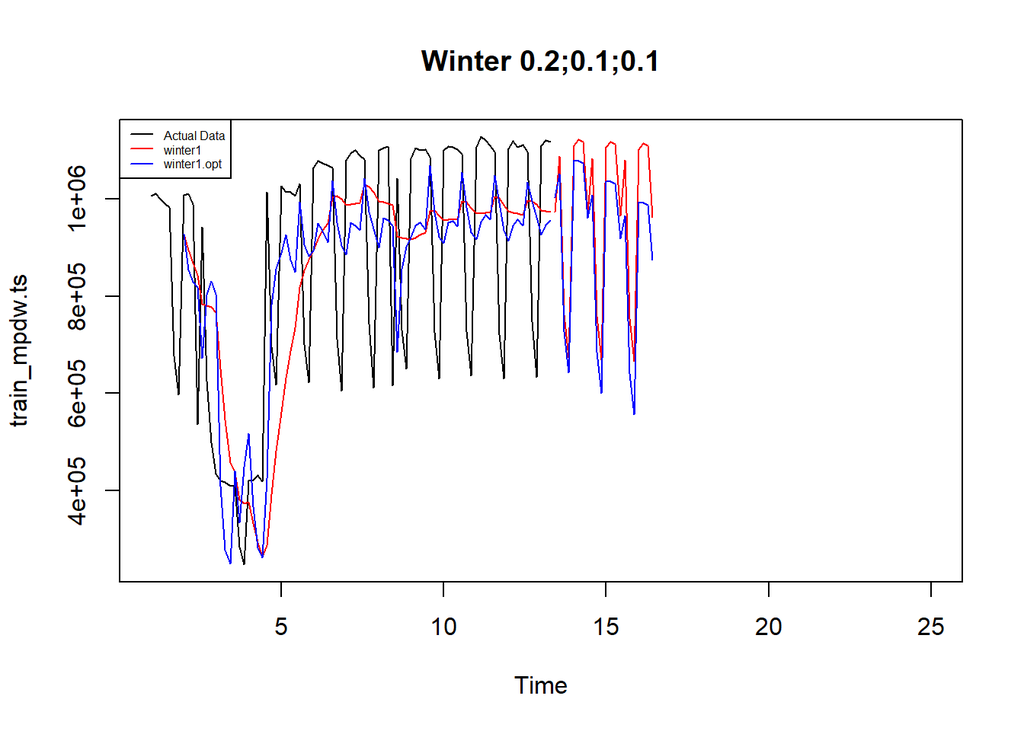

```r
#Plot time series
plot(train_mpdw.ts,main="Winter 0.2;0.1;0.1",type="l",col="black",
     xlim=c(1,25),pch=12)
lines(xhat1,type="l",col="red")
lines(xhat1.opt,type="l",col="blue")
lines(forecast1,type="l",col="red")
lines(forecast1.opt,type="l",col="blue")
legend("topleft",c("Actual Data",expression(paste(winter1)),
                   expression(paste(winter1.opt))),cex=0.5,
       col=c("black","red","blue"),lty=1)
```

#### Akurasi Data Latih

```r
#Akurasi data training
SSE1<-winter1$SSE
MSE1<-winter1$SSE/length(train_mpdw.ts)
RMSE1<-sqrt(MSE1)
akurasi1 <- matrix(c(SSE1,MSE1,RMSE1))
row.names(akurasi1)<- c("SSE", "MSE", "RMSE")
colnames(akurasi1) <- c("Akurasi")
akurasi1
```

```
##           Akurasi
## SSE  2.370986e+12
## MSE  2.725271e+10
## RMSE 1.650840e+05
```

```r
SSE1.opt<-winter1.opt$SSE
MSE1.opt<-winter1.opt$SSE/length(train_mpdw.ts)
RMSE1.opt<-sqrt(MSE1.opt)
akurasi1.opt <- matrix(c(SSE1.opt,MSE1.opt,RMSE1.opt))
row.names(akurasi1.opt)<- c("SSE1.opt", "MSE1.opt", "RMSE1.opt")
colnames(akurasi1.opt) <- c("Akurasi")
akurasi1.opt
```

```
##                Akurasi
## SSE1.opt  1.442684e+12
## MSE1.opt  1.658257e+10
## RMSE1.opt 1.287733e+05
```

```r
akurasi1.train = data.frame(Model_Winter = c("Winter 1","Winter1 optimal"),
                            Nilai_SSE=c(SSE1,SSE1.opt),
                            Nilai_MSE=c(MSE1,MSE1.opt),Nilai_RMSE=c(RMSE1,RMSE1.opt))
akurasi1.train
```

```
##      Model_Winter    Nilai_SSE   Nilai_MSE Nilai_RMSE
## 1        Winter 1 2.370986e+12 27252710986   165084.0
## 2 Winter1 optimal 1.442684e+12 16582573517   128773.3
```

Dari hasil diatas diperoleh nilai akurasi pada data latih dengan metode Winter Aditif, yaitu nilai SSE, nilai MSE, dan nilai RMSE. Dari dua model tersebut kita bisa melihat bahwa model Winter 1 optimal lebih baik dari model Winter 1. Hal ini dapat dilihat dari winter 1 optimal memiliki nilai SSE, MSE, dan RMSE yang lebih kecil dibandingkan dengan winter 1.

#### Akurasi Data Uji

```r
#Akurasi Data Testing
forecast1<-data.frame(forecast1)
test_mpdw.ts<-data.frame(test_mpdw.ts)
selisih1<-forecast1-test_mpdw.ts
SSEtesting1<-sum(selisih1^2)
MSEtesting1<-SSEtesting1/length(test_mpdw.ts)

forecast1.opt<-data.frame(forecast1.opt)
selisih1.opt<-forecast1.opt-test_mpdw.ts
SSEtesting1.opt<-sum(selisih1.opt^2)
MSEtesting1.opt<-SSEtesting1.opt/length(test_mpdw.ts)
```

### Winter Multiplikatif

Model multiplikatif digunakan cocok digunakan jika plot data asli menunjukkan fluktuasi musiman yang bervariasi.

#### Pemulusan

```r
#Pemulusan dengan winter multiplikatif
winter2 <- HoltWinters(train_mpdw.ts,alpha=0.2,beta=0.1,gamma=0.3,seasonal = "multiplicative")
winter2$fitted
```

```
## Time Series:
## Start = c(2, 1)
## End = c(13, 3)
## Frequency = 7
##                xhat    level        trend    season
##  2.000000 1098765.9 927860.2 -15925.85544 1.2048739
##  2.142857 1070235.3 896946.1 -17424.68206 1.2168383
##  2.285714 1023307.9 869828.3 -18393.98575 1.2018635
##  2.428571  727056.7 845879.2 -18949.50454 0.8792243
##  2.571429  826150.9 783364.1 -23306.06433 1.0869577
##  2.714286  568960.0 781328.0 -21179.06180 0.7484849
##  2.857143  500022.9 775265.9 -19667.36888 0.6617574
##  3.000000  868304.7 755121.9 -19715.02788 1.1807133
##  3.142857  761973.9 661758.6 -27079.85912 1.2005663
##  3.285714  649548.9 577538.4 -32793.89440 1.1923918
##  3.428571  384849.1 505711.7 -36697.17317 0.8205482
##  3.571429  492669.0 475013.9 -36097.23405 1.1224659
##  3.714286  295899.3 423891.9 -37599.71207 0.7659986
##  3.857143  228015.5 382773.3 -37951.59982 0.6612562
##  4.000000  320309.7 350484.7 -37385.29920 1.0230288
##  4.142857  314424.3 332613.3 -35433.91198 1.0580287
##  4.285714  307403.1 317519.0 -33399.94677 1.0819517
##  4.428571  229736.8 306919.5 -31119.90319 0.8329844
##  4.571429  316392.4 320994.8 -26600.38962 1.0747231
##  4.714286  311258.1 424468.5 -13592.97364 0.7575483
##  4.857143  343108.7 512441.3  -3436.39539 0.6740774
##  5.000000  651710.5 590434.5   4706.56386 1.0950521
##  5.142857  769252.5 663609.2  11553.37039 1.1393590
##  5.285714  864996.2 718185.4  15855.65750 1.1784030
##  5.428571  757433.1 759474.6  18399.01224 0.9737226
##  5.571429 1253425.0 829181.4  23529.79419 1.4699290
##  5.714286  790596.8 822585.2  20517.18626 0.9377234
##  5.857143  661915.1 823922.5  18599.20474 0.7856356
##  6.000000 1045872.4 832290.8  17576.10691 1.2306309
##  6.142857 1063672.1 853064.8  17895.90391 1.2212629
##  6.285714 1092870.4 873443.1  18144.13780 1.2257583
##  6.428571  948213.7 888643.0  17849.71751 1.0460246
##  6.571429 1335116.1 929853.0  20185.74910 1.4053280
##  6.714286  845827.7 911582.1  16340.08295 0.9115287
##  6.857143  705721.7 898347.6  13382.61794 0.7740467
```

[output cut: 30 more lines]

```
## 11.285714 1119952.3 908532.1   1294.29864 1.2309516
## 11.428571  995526.7 910098.2   1321.47655 1.0922813
## 11.571429 1150768.3 932449.0   3424.40278 1.2296197
## 11.714286  771307.9 927261.4   2563.20528 0.8295198
## 11.857143  661757.6 917707.7   1351.51936 0.7200380
## 12.000000 1121219.1 910151.2    460.71667 1.2312809
## 12.142857 1125465.9 907938.1    193.33486 1.2393205
## 12.285714 1117395.6 907312.8    111.46828 1.2313927
## 12.428571 1016153.4 905837.3    -47.22319 1.1218420
## 12.571429 1124008.4 922763.2   1650.08602 1.2159155
## 12.714286  752162.2 920121.1   1220.87132 0.8163768
## 12.857143  655709.6 920359.8   1122.65099 0.7115812
## 13.000000 1123648.5 915315.5    505.95025 1.2269297
## 13.142857 1131311.6 913558.1    279.62163 1.2379786
## 13.285714 1121149.5 912268.2    122.66238 1.2288040
```

```r
xhat2 <- winter2$fitted[,2]

winter2.opt<- HoltWinters(train_mpdw.ts, alpha= NULL,  beta = NULL, gamma = NULL, seasonal = "multiplicative")
winter2.opt$fitted
```

```
## Time Series:
## Start = c(2, 1)
## End = c(13, 3)
## Frequency = 7
##                xhat     level      trend    season
##  2.000000 1098765.9  927860.2 -15925.855 1.2048739
##  2.142857 1034972.9  867243.3 -16700.587 1.2168383
##  2.285714  987955.8  838922.0 -16902.035 1.2018635
##  2.428571  708753.2  822997.0 -16885.097 0.8792243
##  2.571429  727939.6  688625.4 -18921.757 1.0869577
##  2.714286  576422.9  787007.8 -16888.258 0.7484849
##  2.857143  524799.0  809248.3 -16209.951 0.6617574
##  3.000000  897022.8  769290.2 -16621.632 1.1917900
##  3.142857  606761.6  520739.8 -20642.180 1.2132864
##  3.285714  463498.2  407795.4 -22242.264 1.2021642
##  3.428571  287987.9  362406.3 -22643.520 0.8476146
##  3.571429  452997.2  425227.8 -21161.962 1.1210977
##  3.714286  271247.5  380313.9 -21573.708 0.7561112
##  3.857143  227565.8  367553.6 -21420.926 0.6574526
##  4.000000  369774.9  363523.8 -21119.445 1.0799364
##  4.142857  403900.3  370208.5 -20637.452 1.1554169
##  4.285714  401396.4  358925.3 -20475.295 1.1859843
##  4.428571  294200.6  353208.8 -20219.446 0.8835135
##  4.571429  440058.9  416531.0 -18771.230 1.1063435
##  4.714286  527747.2  707862.1 -13395.521 0.7599317
##  4.857143  541467.8  826471.9 -11107.173 0.6640805
##  5.000000  958551.4  883694.0  -9922.666 1.0970278
##  5.142857 1047301.2  910757.8  -9281.495 1.1617623
##  5.285714 1046855.4  884559.5  -9574.753 1.1964271
##  5.428571  781972.2  859032.4  -9851.291 0.9208544
##  5.571429 1193655.9  995059.2  -7322.455 1.2084757
##  5.714286  706379.6  907968.8  -8705.254 0.7855090
##  5.857143  598062.4  894928.9  -8780.397 0.6749009
##  6.000000  994269.3  907057.8  -8417.928 1.1064158
##  6.142857 1075283.5  937059.4  -7751.914 1.1570804
##  6.285714 1100475.6  931135.4  -7720.228 1.1917452
##  6.428571  856875.6  910580.1  -7942.727 0.9493022
##  6.571429 1223049.5 1036766.7  -5617.558 1.1861033
##  6.714286  741263.2  951632.5  -6996.001 0.7847073
##  6.857143  620040.1  921665.8  -7394.204 0.6781793
```

[output cut: 30 more lines]

```
## 11.285714 1132270.0  961897.2  -3777.174 1.1817623
## 11.428571  943691.6  952748.2  -3870.294 0.9945342
## 11.571429 1194437.2 1048826.0  -2137.667 1.1411584
## 11.714286  773302.4  996198.6  -3012.921 0.7786081
## 11.857143  643283.1  953166.4  -3706.667 0.6775254
## 12.000000 1073561.0  937492.6  -3914.119 1.1499419
## 12.142857 1104190.8  949756.9  -3633.662 1.1670686
## 12.285714 1122416.9  954402.2  -3490.143 1.1803582
## 12.428571  953451.8  943438.9  -3619.694 1.0145055
## 12.571429 1163550.8 1032640.3  -2010.615 1.1289708
## 12.714286  766585.3  995958.9  -2611.642 0.7717194
## 12.857143  659651.7  979103.6  -2858.559 0.6757030
## 13.000000 1096535.4  953401.2  -3254.563 1.1540697
## 13.142857 1115238.9  956982.3  -3136.066 1.1692020
## 13.285714 1124192.5  957088.7  -3079.857 1.1783879
```

```r
xhat2.opt <- winter2.opt$fitted[,2]
```

#### Peramalan

```r
#Forecast
forecast2 <- predict(winter2, n.ahead = 22)
forecast2.opt <- predict(winter2.opt, n.ahead = 22)
```

#### Plot Deret Waktu

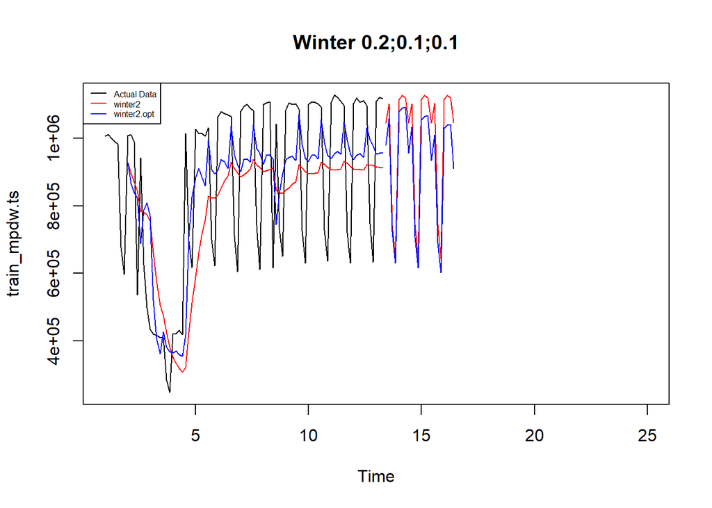

```r
#Plot time series
plot(train_mpdw.ts,main="Winter 0.2;0.1;0.1",type="l",col="black",
     xlim=c(1,25),pch=12)
lines(xhat2,type="l",col="red")
lines(xhat2.opt,type="l",col="blue")
lines(forecast2,type="l",col="red")
lines(forecast2.opt,type="l",col="blue")
legend("topleft",c("Actual Data",expression(paste(winter2)),
                   expression(paste(winter2.opt))),cex=0.5,
       col=c("black","red","blue"),lty=1)
```

#### Akurasi Data Latih

```r
#Akurasi data training
SSE2<-winter2$SSE
MSE2<-winter2$SSE/length(train_mpdw.ts)
RMSE2<-sqrt(MSE2)
akurasi1 <- matrix(c(SSE2,MSE2,RMSE2))
row.names(akurasi1)<- c("SSE2", "MSE2", "RMSE2")
colnames(akurasi1) <- c("Akurasi lamda=0.2")
akurasi1
```

```
##       Akurasi lamda=0.2
## SSE2       2.042515e+12
## MSE2       2.347719e+10
## RMSE2      1.532227e+05
```

```r
SSE2.opt<-winter2.opt$SSE
MSE2.opt<-winter2.opt$SSE/length(train_mpdw.ts)
RMSE2.opt<-sqrt(MSE2.opt)
akurasi1.opt <- matrix(c(SSE2.opt,MSE2.opt,RMSE2.opt))
row.names(akurasi1.opt)<- c("SSE2.opt", "MSE2.opt", "RMSE2.opt")
colnames(akurasi1.opt) <- c("Akurasi")
akurasi1.opt
```

```
##                Akurasi
## SSE2.opt  1.330806e+12
## MSE2.opt  1.529662e+10
## RMSE2.opt 1.236795e+05
```

```r
akurasi2.train = data.frame(Model_Winter = c("Winter 1","winter2 optimal"),
                            Nilai_SSE=c(SSE2,SSE2.opt),
                            Nilai_MSE=c(MSE2,MSE2.opt),Nilai_RMSE=c(RMSE2,RMSE2.opt))
akurasi2.train
```

```
##      Model_Winter    Nilai_SSE   Nilai_MSE Nilai_RMSE
## 1        Winter 1 2.042515e+12 23477189279   153222.7
## 2 winter2 optimal 1.330806e+12 15296623320   123679.5
```

#### Akurasi Data Uji

```r
#Akurasi Data Testing
forecast2<-data.frame(forecast2)
test_mpdw.ts<-data.frame(test_mpdw.ts)
selisih2<-forecast2-test_mpdw.ts
SSEtesting2<-sum(selisih2^2)
MSEtesting2<-SSEtesting2/length(test_mpdw.ts)

forecast2.opt<-data.frame(forecast2.opt)
selisih2.opt<-forecast2.opt-test_mpdw.ts
SSEtesting2.opt<-sum(selisih2.opt^2)
MSEtesting2.opt<-SSEtesting2.opt/length(test_mpdw.ts)
```